# Analyzing University of Maryland CMSC Department from 2012 to 2020

## Michael Lacanilao, Alex Juan, and Yong Tae Kwon

[figure not shown]

1. Motivation
2. Setting Up the Environment
3. Data Collection/Curation + Parsing  
   3.1 Data Collection  
   3.2 Data Curation
4. Data Management/Representation/Exploratory Data Analysis  
   4.1 Data Management  
   4.2 Data Representation and Exploratory Data Analysis  
   4.2.1 What are top 10 biggest departments over time?  
   4.2.2 How does the CMSC department pass rate compare to other departments?  
   4.2.3 What are the top 10 highest average pass rate CMSC courses?  
   4.2.4 What are the top 10 highest average pass rate CMSC professors?  
   4.2.5 What are the top 10 highest average pass rate CMSC courses and professors?  
   4.2.6 What are the top 10 highest average pass rate departments for Upper Level Concentration?  
   4.2.7 What professors should computer science majors choose for their required courses?
5. Hypothesis Testing and Machine Learning  
   5.1 What will the average passing percentage be for the CMSC department in 2021?  
   5.2 How has COVID-19 impacted the pass rate in 2020?
6. Communication of Insights Attained

## 1. Motivation

As a University of Maryland (UMD) Computer Science (CS) student, have you ever struggled with deciding the courses to enroll in? Have you ever encountered a poorly managed course/professor?

UMD students are required to have a minimum of 120 credits, in addition to other requirements, to graduate with their bachelor's degree. There are so many departments students can take classes from and it can be difficult at times to choose which course to take from which department. From libraries to classrooms, there is one commonality we are all concerned about. You may have already guessed it, it is indeed the struggle of what courses to take every semester. Selecting what classes to enroll in was a constant struggle every semester. Even though we all had 4-year plans prepped, it was persistently changing for a multitude of reasons. A couple of those reasons being classes filling up before we could sign up or our interests would change.

When things don't go as planned, it can be very stressful, especially when students have to plan in the middle of their semesters. We would like to help alleviate that stress for CS students. In this tutorial, we will analyze UMD departments, shed light on the CMSC department, and provide CMSC general requirement recommendations, at the minimum, to help smoothen out the experience for fellow peers.

## 2. Setting Up the Environment

We will be using [PlanetTerp's API Python wrapper](https://github.com/planetterp/PlanetTerp-API-Python-Wrapper), [pandas](https://pandas.pydata.org/) for data analysis and manipulation, [matplotlib](https://matplotlib.org/) for our plotting library, [seaborn](https://seaborn.pydata.org/) for simple data visualization, and [scikit-learn](https://scikit-learn.org/) for predictive data analysis. Here is a list with links to the documentation:

- [PlanetTerp's API Python wrapper](https://github.com/planetterp/PlanetTerp-API-Python-Wrapper)
- [pandas](https://pandas.pydata.org/)
- [matplotlib](https://matplotlib.org/)
- [seaborn](https://seaborn.pydata.org/)
- [scikit-learn](https://scikit-learn.org/)

```python
!pip install planetterp
import planetterp
import pandas as pd
import numpy as np
import seaborn as sns
import matplotlib.pyplot as plt
from sklearn.linear_model import LinearRegression
import warnings

# Ignore warnings.
warnings.filterwarnings('ignore')
```

## 3. Data Collection/Curation + Parsing

### 3.1. Data Collection

First, we needed to get a list of all departments. This information can be found on [Testudo's Schedule of Classes](https://app.testudo.umd.edu/soc/). We learned that there are **184** different departments. We used that information to request a list of courses from PlanetTerp's API and took the list of courses to get a list of all sections. It takes more than 15 minutes to make all the requests, so we ran the code once and saved the DataFrame to a CSV file to save time. The following is the code we used to accomplish this:

```
{python}
# Create empty DataFrame to hold sections.
df = pd.DataFrame()

# Create department list.
department_list = ['AASP', 'AAST', 'AGNR', 'AGST', 'AMSC', 'AMST', 'ANSC', 'ANTH', 'AOSC', 'ARAB', 'ARCH', 'AREC', 'ARHU', 'ARMY', 'ARSC', 'ARTH', 'ARTT', 'ASTR', 'BCHM', 'BIOE', 'BIOL', 'BIOM', 'BIPH', 'BISI', 'BMGT', 'BMSO', 'BSCI', 'BSCV', 'BSGC', 'BSOS', 'BSST', 'BUAC', 'BUDT', 'BUFN', 'BULM', 'BUMK', 'BUSI', 'BUSM', 'BUSO', 'CBMG', 'CCJS', 'CHBE', 'CHEM', 'CHIN', 'CHPH', 'CHSE', 'CLAS', 'CLFS', 'CMLT', 'CMSC', 'COMM', 'CPBE', 'CPET', 'CPGH', 'CPJT', 'CPMS', 'CPPL', 'CPSA', 'CPSD', 'CPSF', 'CPSG', 'CPSN', 'CPSP', 'CPSS', 'DANC', 'DATA', 'ECON', 'EDCP', 'EDHD', 'EDHI', 'EDMS', 'EDSP', 'EDUC', 'ENAE', 'ENBC', 'ENCE', 'ENCH', 'ENCO', 'ENEB', 'ENEE', 'ENES', 'ENFP', 'ENGL', 'ENMA', 'ENME', 'ENPM', 'ENRE', 'ENSE', 'ENSP', 'ENST', 'ENTM', 'ENTS', 'EPIB', 'FGSM', 'FILM', 'FIRE', 'FMSC', 'FREN', 'GEMS', 'GEOG', 'GEOL', 'GERM', 'GREK', 'GVPT', 'HACS', 'HDCC', 'HEBR', 'HESI', 'HESP', 'HHUM', 'HISP', 'HIST', 'HLSA', 'HLSC', 'HLTH', 'HNUH', 'HONR', 'IDEA', 'IMDM', 'IMMR', 'INAG', 'INFM', 'INST', 'ISRL', 'ITAL', 'JAPN', 'JOUR', 'JWST', 'KNES', 'KORA', 'LARC', 'LASC', 'LATN', 'LBSC', 'LGBT', 'LING', 'MATH', 'MEES', 'MIEH', 'MITH', 'MLAW', 'MLSC', 'MOCB', 'MSML', 'MUED', 'MUSC', 'MUSP', 'NACS', 'NAVY', 'NEUR', 'NFSC', 'NIAS', 'PEER', 'PERS', 'PHIL', 'PHPE', 'PHSC', 'PHYS', 'PLCY', 'PLSC', 'PORT', 'PSYC', 'RDEV', 'RELS', 'RUSS', 'SLAA', 'SLLC', 'SMLP', 'SOCY', 'SPAN', 'SPHL', 'STAT', 'SURV', 'TDPS', 'THET', 'TLPL', 'TLTC', 'UMEI', 'UNIV', 'URSP', 'USLT', 'VMSC', 'WGSS', 'WMST']

# Get sections from all departments.
for department in department_list:
    # Create empty section list.
    section_list = []

    # Get all courses from department.
    courses = planetterp.courses(department=department)

    try:
        # Get all sections from courses.
        for course in courses:
                for section in planetterp.grades(course=f'{department}{course["course_number"]}'):
                    section_list.append(section)
    except:
        print('error')

    # Add sections to DataFrame.
    df = df.append(pd.DataFrame(section_list), ignore_index=True)

# Save DataFrame to a CSV file.
df.to_csv('data.csv')
```

After making all the requests, we ended up with **93,709** sections up to Fall 2020 semester, and we saved the DataFrame to a CSV file named "data.csv." We moved it into our data folder to keep it separated from our notebook. We ran the following code to access the dataset from the CSV file and read it into a pandas DataFrame:

```python
# Read data from CSV file.
df = pd.read_csv('data/data.csv')

# Print DataFrame.
df
```

|  | Unnamed: 0 | A | C+ | C | B | D+ | C- | F | B- | professor | A- | A+ | course | semester | D- | W | B+ | Other | section | D |
| --- | --- | --- | --- | --- | --- | --- | --- | --- | --- | --- | --- | --- | --- | --- | --- | --- | --- | --- | --- | --- |
| 0 | 0 | 9 | 1 | 1 | 4 | 0 | 0 | 2 | 0 | Jason Nichols | 7 | 1 | AASP100 | 202008 | 0 | 2 | 8 | 1 | 0501 | 0 |
| 1 | 1 | 11 | 0 | 1 | 5 | 1 | 0 | 0 | 2 | Jason Nichols | 7 | 1 | AASP100 | 202008 | 0 | 1 | 6 | 0 | 0601 | 1 |
| 2 | 2 | 12 | 0 | 0 | 0 | 0 | 0 | 0 | 0 | Shane Walsh | 15 | 5 | AASP100 | 202008 | 0 | 2 | 2 | 0 | 0101 | 0 |
| 3 | 3 | 16 | 1 | 0 | 2 | 0 | 0 | 0 | 0 | Shane Walsh | 13 | 2 | AASP100 | 202008 | 0 | 1 | 1 | 0 | 0201 | 0 |
| 4 | 4 | 15 | 0 | 0 | 0 | 0 | 0 | 0 | 0 | Shane Walsh | 16 | 0 | AASP100 | 202008 | 0 | 1 | 4 | 0 | 0701 | 0 |
| ... | ... | ... | ... | ... | ... | ... | ... | ... | ... | ... | ... | ... | ... | ... | ... | ... | ... | ... | ... | ... |
| 93704 | 93704 | 2 | 2 | 0 | 0 | 0 | 1 | 0 | 0 | Ashwini Tambe | 2 | 3 | WMST488T | 201401 | 0 | 0 | 6 | 0 | 0101 | 0 |
| 93705 | 93705 | 4 | 1 | 0 | 1 | 0 | 1 | 0 | 0 | Catherine Schuler | 1 | 2 | WMST488T | 201201 | 0 | 3 | 0 | 1 | 0101 | 0 |
| 93706 | 93706 | 3 | 0 | 0 | 2 | 0 | 0 | 0 | 0 | Augusta Bolles | 4 | 1 | WMST488W | 201408 | 0 | 1 | 0 | 0 | 0101 | 0 |
| 93707 | 93707 | 3 | 0 | 0 | 0 | 0 | 0 | 0 | 0 | Ashwini Tambe | 2 | 5 | WMST488X | 202001 | 0 | 0 | 0 | 2 | 0101 | 0 |
| 93708 | 93708 | 4 | 0 | 0 | 2 | 0 | 0 | 0 | 0 | Alexis Lothian | 1 | 0 | WMST488X | 201901 | 0 | 0 | 1 | 0 | 0101 | 0 |

93709 rows × 20 columns

A quick look at the DataFrame reveals that the columns are in the wrong order. We will need to reorder the columns and possibly clean the data for any missing values.

### 3.2 Data Curation

```python
# Change the column order.
df = df[['course', 'section', 'professor', 'semester', 'A+', 'A', 'A-', 'B+', 'B', 'B-', 'C+', 'C', 'C-', 'D+', 'D', 'D-', 'F', 'W', 'Other']]

# Print DataFrame.
df
```

|  | course | section | professor | semester | A+ | A | A- | B+ | B | B- | C+ | C | C- | D+ | D | D- | F | W | Other |
| --- | --- | --- | --- | --- | --- | --- | --- | --- | --- | --- | --- | --- | --- | --- | --- | --- | --- | --- | --- |
| 0 | AASP100 | 0501 | Jason Nichols | 202008 | 1 | 9 | 7 | 8 | 4 | 0 | 1 | 1 | 0 | 0 | 0 | 0 | 2 | 2 | 1 |
| 1 | AASP100 | 0601 | Jason Nichols | 202008 | 1 | 11 | 7 | 6 | 5 | 2 | 0 | 1 | 0 | 1 | 1 | 0 | 0 | 1 | 0 |
| 2 | AASP100 | 0101 | Shane Walsh | 202008 | 5 | 12 | 15 | 2 | 0 | 0 | 0 | 0 | 0 | 0 | 0 | 0 | 0 | 2 | 0 |
| 3 | AASP100 | 0201 | Shane Walsh | 202008 | 2 | 16 | 13 | 1 | 2 | 0 | 1 | 0 | 0 | 0 | 0 | 0 | 0 | 1 | 0 |
| 4 | AASP100 | 0701 | Shane Walsh | 202008 | 0 | 15 | 16 | 4 | 0 | 0 | 0 | 0 | 0 | 0 | 0 | 0 | 0 | 1 | 0 |
| ... | ... | ... | ... | ... | ... | ... | ... | ... | ... | ... | ... | ... | ... | ... | ... | ... | ... | ... | ... |
| 93704 | WMST488T | 0101 | Ashwini Tambe | 201401 | 3 | 2 | 2 | 6 | 0 | 0 | 2 | 0 | 1 | 0 | 0 | 0 | 0 | 0 | 0 |
| 93705 | WMST488T | 0101 | Catherine Schuler | 201201 | 2 | 4 | 1 | 0 | 1 | 0 | 1 | 0 | 1 | 0 | 0 | 0 | 0 | 3 | 1 |
| 93706 | WMST488W | 0101 | Augusta Bolles | 201408 | 1 | 3 | 4 | 0 | 2 | 0 | 0 | 0 | 0 | 0 | 0 | 0 | 0 | 1 | 0 |
| 93707 | WMST488X | 0101 | Ashwini Tambe | 202001 | 5 | 3 | 2 | 0 | 0 | 0 | 0 | 0 | 0 | 0 | 0 | 0 | 0 | 0 | 2 |
| 93708 | WMST488X | 0101 | Alexis Lothian | 201901 | 0 | 4 | 1 | 1 | 2 | 0 | 0 | 0 | 0 | 0 | 0 | 0 | 0 | 0 | 0 |

93709 rows × 19 columns

Now that the columns are in a presentable order, we would like to see if there are any missing data.

```python
# Count the number of missing columns in each column.
for column in df.columns:
  print('Number of NaN values in column {}: {}'.format(str(column), df[column].isnull().sum()))
```

```
Number of NaN values in column course: 0
Number of NaN values in column section: 0
Number of NaN values in column professor: 6155
Number of NaN values in column semester: 0
Number of NaN values in column A+: 0
Number of NaN values in column A: 0
Number of NaN values in column A-: 0
Number of NaN values in column B+: 0
Number of NaN values in column B: 0
Number of NaN values in column B-: 0
Number of NaN values in column C+: 0
Number of NaN values in column C: 0
Number of NaN values in column C-: 0
Number of NaN values in column D+: 0
Number of NaN values in column D: 0
Number of NaN values in column D-: 0
Number of NaN values in column F: 0
Number of NaN values in column W: 0
Number of NaN values in column Other: 0
```

We can see by counting the number of NaN or null values, there are missing values for professor. This might mean that the section was entered into the database incorrectly. We decided to keep these sections because it is still valuable for course analysis.

Additionally, there are no other missing values in the other columns. We do not need to do additional cleaning for missing data, but we do need to remove courses that have appeared for only 1 semester because it could be the professor's first time teaching that class. The data would not be as reliable since professors may not be as experienced when they only taught the course once. We agreed that these 1 semester courses is not enough to say that they will grade and teach the class the same way next time. Thus, the following code will remove the courses taht appeared for only 1 semester.

```python
# Group the DataFrame by course and semester.
df_new = df.groupby(['course', 'semester']).count().reset_index()

# Group the new DataFrame by course to count semester.
df_new = df_new.groupby(['course']).count().reset_index()

# Keep courses with more than 2 semesters.
df_new = df_new[df_new['semester'] >= 2]

# Save the courses to keep in a list.
keep_lst = df_new['course'].tolist()

# Remove the course rows that is not in keep_lst list.
df = df[df['course'].isin(keep_lst)]

# Print DataFrame.
df
```

|  | course | section | professor | semester | A+ | A | A- | B+ | B | B- | C+ | C | C- | D+ | D | D- | F | W | Other |
| --- | --- | --- | --- | --- | --- | --- | --- | --- | --- | --- | --- | --- | --- | --- | --- | --- | --- | --- | --- |
| 0 | AASP100 | 0501 | Jason Nichols | 202008 | 1 | 9 | 7 | 8 | 4 | 0 | 1 | 1 | 0 | 0 | 0 | 0 | 2 | 2 | 1 |
| 1 | AASP100 | 0601 | Jason Nichols | 202008 | 1 | 11 | 7 | 6 | 5 | 2 | 0 | 1 | 0 | 1 | 1 | 0 | 0 | 1 | 0 |
| 2 | AASP100 | 0101 | Shane Walsh | 202008 | 5 | 12 | 15 | 2 | 0 | 0 | 0 | 0 | 0 | 0 | 0 | 0 | 0 | 2 | 0 |
| 3 | AASP100 | 0201 | Shane Walsh | 202008 | 2 | 16 | 13 | 1 | 2 | 0 | 1 | 0 | 0 | 0 | 0 | 0 | 0 | 1 | 0 |
| 4 | AASP100 | 0701 | Shane Walsh | 202008 | 0 | 15 | 16 | 4 | 0 | 0 | 0 | 0 | 0 | 0 | 0 | 0 | 0 | 1 | 0 |
| ... | ... | ... | ... | ... | ... | ... | ... | ... | ... | ... | ... | ... | ... | ... | ... | ... | ... | ... | ... |
| 93703 | WMST488P | 0101 | Catherine Schuler | 201508 | 0 | 5 | 1 | 2 | 0 | 0 | 1 | 0 | 0 | 0 | 1 | 0 | 2 | 0 | 0 |
| 93704 | WMST488T | 0101 | Ashwini Tambe | 201401 | 3 | 2 | 2 | 6 | 0 | 0 | 2 | 0 | 1 | 0 | 0 | 0 | 0 | 0 | 0 |
| 93705 | WMST488T | 0101 | Catherine Schuler | 201201 | 2 | 4 | 1 | 0 | 1 | 0 | 1 | 0 | 1 | 0 | 0 | 0 | 0 | 3 | 1 |
| 93707 | WMST488X | 0101 | Ashwini Tambe | 202001 | 5 | 3 | 2 | 0 | 0 | 0 | 0 | 0 | 0 | 0 | 0 | 0 | 0 | 0 | 2 |
| 93708 | WMST488X | 0101 | Alexis Lothian | 201901 | 0 | 4 | 1 | 1 | 2 | 0 | 0 | 0 | 0 | 0 | 0 | 0 | 0 | 0 | 0 |

91623 rows × 19 columns

We were able to remove **2,086** sections from the DataFrame. These are courses that only appeared for one semester. The above dataframe is the courses that existed for at least 2 semesters, and we will proceed to analyze the rest of the data.

## 4. Data Management/Representation/Exploratory Data Analysis

### 4.1 Data Management

First, we need to add more columns to the DataFrame. Adding the total number of grades, the total number of passing grades, and the passing percentage would be useful information. We consider passing as having a C- or above.

```python
# Get the total number grades.
df['number_of_grades'] = df[['A+', 'A', 'A-', 'B+', 'B', 'B-', 'C+', 'C', 'C-', 'D+', 'D', 'D-', 'F', 'W', 'Other']].sum(axis=1)

# Get the total number of passing grades.
df['passing_grades'] = df[['A+', 'A', 'A-', 'B+', 'B', 'B-', 'C+', 'C', 'C-', 'Other']].sum(axis=1)

# Get the pass percentages.
df['passing_percentage'] = ((df['passing_grades'] / df['number_of_grades']) * 100).round(2)

# Covert column as strings.
df['semester'] = df['semester'].astype(str)

# Create year and department columns.
df['year'] = df['semester'].str[0:4]
df['department'] = df['course'].str[0:4]

# Display dataframe.
df
```

|  | course | section | professor | semester | A+ | A | A- | B+ | B | B- | ... | D | D- | F | W | Other | number_of_grades | passing_grades | passing_percentage | year | department |
| --- | --- | --- | --- | --- | --- | --- | --- | --- | --- | --- | --- | --- | --- | --- | --- | --- | --- | --- | --- | --- | --- |
| 0 | AASP100 | 0501 | Jason Nichols | 202008 | 1 | 9 | 7 | 8 | 4 | 0 | ... | 0 | 0 | 2 | 2 | 1 | 36 | 32 | 88.89 | 2020 | AASP |
| 1 | AASP100 | 0601 | Jason Nichols | 202008 | 1 | 11 | 7 | 6 | 5 | 2 | ... | 1 | 0 | 0 | 1 | 0 | 36 | 33 | 91.67 | 2020 | AASP |
| 2 | AASP100 | 0101 | Shane Walsh | 202008 | 5 | 12 | 15 | 2 | 0 | 0 | ... | 0 | 0 | 0 | 2 | 0 | 36 | 34 | 94.44 | 2020 | AASP |
| 3 | AASP100 | 0201 | Shane Walsh | 202008 | 2 | 16 | 13 | 1 | 2 | 0 | ... | 0 | 0 | 0 | 1 | 0 | 36 | 35 | 97.22 | 2020 | AASP |
| 4 | AASP100 | 0701 | Shane Walsh | 202008 | 0 | 15 | 16 | 4 | 0 | 0 | ... | 0 | 0 | 0 | 1 | 0 | 36 | 35 | 97.22 | 2020 | AASP |
| ... | ... | ... | ... | ... | ... | ... | ... | ... | ... | ... | ... | ... | ... | ... | ... | ... | ... | ... | ... | ... | ... |
| 93703 | WMST488P | 0101 | Catherine Schuler | 201508 | 0 | 5 | 1 | 2 | 0 | 0 | ... | 1 | 0 | 2 | 0 | 0 | 12 | 9 | 75.00 | 2015 | WMST |
| 93704 | WMST488T | 0101 | Ashwini Tambe | 201401 | 3 | 2 | 2 | 6 | 0 | 0 | ... | 0 | 0 | 0 | 0 | 0 | 16 | 16 | 100.00 | 2014 | WMST |
| 93705 | WMST488T | 0101 | Catherine Schuler | 201201 | 2 | 4 | 1 | 0 | 1 | 0 | ... | 0 | 0 | 0 | 3 | 1 | 14 | 11 | 78.57 | 2012 | WMST |
| 93707 | WMST488X | 0101 | Ashwini Tambe | 202001 | 5 | 3 | 2 | 0 | 0 | 0 | ... | 0 | 0 | 0 | 0 | 2 | 12 | 12 | 100.00 | 2020 | WMST |
| 93708 | WMST488X | 0101 | Alexis Lothian | 201901 | 0 | 4 | 1 | 1 | 2 | 0 | ... | 0 | 0 | 0 | 0 | 0 | 8 | 8 | 100.00 | 2019 | WMST |

91623 rows × 24 columns

### 4.2 Data Representation and Exploratory Data Analysis

Now that we calculated passing percentages, we can calculate the average passing percentage for departments over the years.

```python
# Groupby year and department.
df_mean = df.groupby(['department', 'year']).mean().reset_index()
df_mean
```

|  | department | year | A+ | A | A- | B+ | B | B- | C+ | C | C- | D+ | D | D- | F | W | Other | number_of_grades | passing_grades | passing_percentage |
| --- | --- | --- | --- | --- | --- | --- | --- | --- | --- | --- | --- | --- | --- | --- | --- | --- | --- | --- | --- | --- |
| 0 | AASP | 2012 | 2.058824 | 4.490196 | 4.274510 | 3.000000 | 4.803922 | 2.176471 | 0.921569 | 1.627451 | 0.647059 | 0.078431 | 0.392157 | 0.078431 | 0.490196 | 1.607843 | 0.490196 | 27.137255 | 24.490196 | 89.286863 |
| 1 | AASP | 2013 | 2.311111 | 5.200000 | 5.355556 | 3.511111 | 4.288889 | 2.222222 | 0.977778 | 1.444444 | 0.511111 | 0.200000 | 0.355556 | 0.066667 | 0.533333 | 1.666667 | 0.377778 | 29.022222 | 26.200000 | 89.479333 |
| 2 | AASP | 2014 | 1.285714 | 6.734694 | 4.448980 | 4.081633 | 4.795918 | 2.285714 | 0.816327 | 1.591837 | 0.571429 | 0.081633 | 0.408163 | 0.081633 | 0.591837 | 1.693878 | 0.653061 | 30.122449 | 27.265306 | 87.352449 |
| 3 | AASP | 2015 | 1.956522 | 8.456522 | 5.434783 | 4.195652 | 5.565217 | 2.282609 | 0.543478 | 0.913043 | 0.347826 | 0.086957 | 0.130435 | 0.086957 | 0.739130 | 1.847826 | 0.652174 | 33.239130 | 30.347826 | 90.444348 |
| 4 | AASP | 2016 | 1.755102 | 6.551020 | 6.959184 | 4.612245 | 4.714286 | 2.673469 | 1.040816 | 1.244898 | 0.775510 | 0.204082 | 0.408163 | 0.122449 | 0.591837 | 1.326531 | 0.571429 | 33.551020 | 30.897959 | 92.408367 |
| ... | ... | ... | ... | ... | ... | ... | ... | ... | ... | ... | ... | ... | ... | ... | ... | ... | ... | ... | ... | ... |
| 1423 | WMST | 2016 | 2.750000 | 8.375000 | 4.395833 | 2.395833 | 1.625000 | 0.750000 | 0.541667 | 0.250000 | 0.125000 | 0.083333 | 0.187500 | 0.041667 | 0.395833 | 0.625000 | 0.395833 | 22.937500 | 21.604167 | 94.358542 |
| 1424 | WMST | 2017 | 2.560976 | 9.000000 | 4.634146 | 2.536585 | 1.390244 | 0.804878 | 0.414634 | 0.268293 | 0.170732 | 0.048780 | 0.097561 | 0.097561 | 0.146341 | 0.878049 | 0.146341 | 23.195122 | 21.926829 | 94.140244 |
| 1425 | WMST | 2018 | 4.404762 | 8.452381 | 5.428571 | 1.976190 | 2.238095 | 0.547619 | 0.428571 | 0.285714 | 0.238095 | 0.119048 | 0.142857 | 0.023810 | 0.476190 | 0.976190 | 0.214286 | 25.952381 | 24.214286 | 93.148333 |
| 1426 | WMST | 2019 | 2.681818 | 7.954545 | 5.545455 | 2.590909 | 2.136364 | 0.750000 | 0.272727 | 0.363636 | 0.250000 | 0.068182 | 0.090909 | 0.181818 | 0.386364 | 0.886364 | 0.227273 | 24.386364 | 22.772727 | 93.219545 |
| 1427 | WMST | 2020 | 8.066667 | 8.000000 | 2.555556 | 1.000000 | 0.555556 | 0.200000 | 0.022222 | 0.133333 | 0.066667 | 0.022222 | 0.022222 | 0.000000 | 0.400000 | 0.822222 | 1.888889 | 23.755556 | 22.488889 | 93.535556 |

1428 rows × 20 columns

We can see the average passing percentages of all departments from 2012 to 2020 in the above dataframe. We decided that a scatter plot is the best way to present this information.

[figure not shown]

```python
# Create a scatter plot of passing percentages over the year

# Set plot size.
fig = plt.figure(figsize=(12, 8))

# Plot scatter plot.
sns.scatterplot(data=df,
                x='year',
                y='passing_percentage',
                hue='department')

# Set labels.
plt.xlabel('Year',
           size=15)
plt.ylabel('Passing Percentages',
           size=15)
plt.gca().invert_xaxis()

# Set legend.
plt.legend(title='Departments',
           bbox_to_anchor=(1.01, 1),
           borderaxespad=0,
           ncol=6)

# Set title.
plt.title('Students Passing Percentages Over the Years',
          size=18)

# Show plot.
plt.show()
```

From the scatter plot above, we can say that students are passing more in all departments. Although there are deparmetns with low passing percentages each year, the concentration of dots are moving closer to the top over the years.

### 4.2.1 What are top 10 biggest departments over time?

Now we want to know the total number of students in each department to see how the top 10 biggest departments change over time.

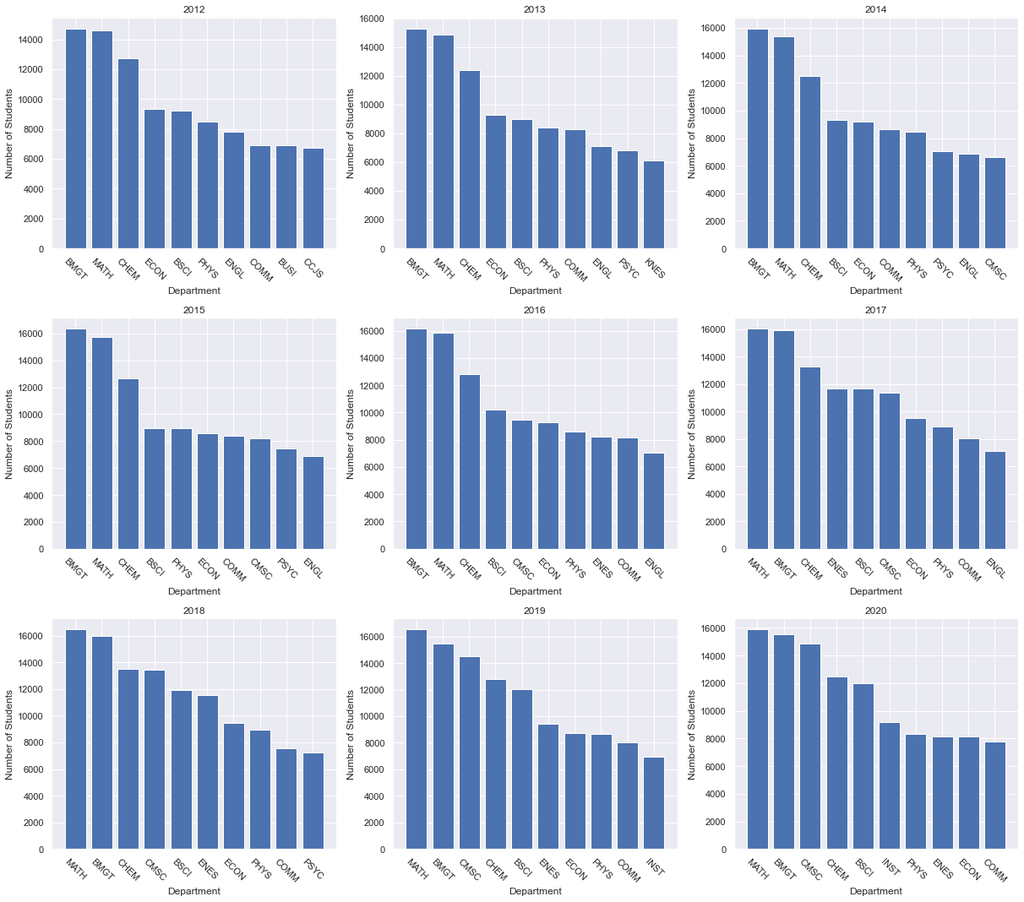

```python
# Goal is to make barcharts of total students per year (2012-2020) for each department.
# Group dataframe by department and year.
spy_df = df.groupby(['year','department']).sum().reset_index()

# Create a dataframe with the top most popular departments for each year.
top10 = pd.DataFrame()
for i,e in spy_df.groupby('year'):
  e = e.nlargest(10, columns='number_of_grades')
  top10 = pd.concat([top10, e])

plt.figure(figsize=(17,15))

# Make barplots according to year and department.
for i,e in top10.groupby('year'):
  if i == '2012':
    plt.subplot(3,3,1)
    plt.bar(e['department'], e['number_of_grades'])
    plt.title(i)
  elif i == '2013':
    plt.subplot(3,3,2)
    plt.bar(e['department'], e['number_of_grades'])
    plt.title(i)
  elif i == '2014':
    plt.subplot(3,3,3)
    plt.bar(e['department'], e['number_of_grades'])
    plt.title(i)
  elif i == '2015':
    plt.subplot(3,3,4)
    plt.bar(e['department'], e['number_of_grades'])
    plt.title(i)
  elif i == '2016':
    plt.subplot(3,3,5)
    plt.bar(e['department'], e['number_of_grades'])
    plt.title(i)
  elif i == '2017':
    plt.subplot(3,3,6)
    plt.bar(e['department'], e['number_of_grades'])
    plt.title(i)
  elif i == '2018':
    plt.subplot(3,3,7)
    plt.bar(e['department'], e['number_of_grades'])
    plt.title(i)
  elif i == '2019':
    plt.subplot(3,3,8)
    plt.bar(e['department'], e['number_of_grades'])
    plt.title(i)
  elif i == '2020':
    plt.subplot(3,3,9)
    plt.bar(e['department'], e['number_of_grades'])
    plt.title(i)
  plt.xticks(rotation=315)
  plt.ylabel('Number of Students')
  plt.xlabel('Department')

plt.tight_layout()

# Show plot.
plt.show()
```

We can see that BMGT and Math departments are the two largest student bodies at UMD. Surprisingly, the CMSC department is not in the top 10 biggest departments until 2014. The CMSC department continued to grow rapidly over the years and is now (in 2020) the third biggest department, passing CHEM at No. 3 since 2012.

### 4.2.2 How does the CMSC department pass rate compare to other departments?

We always hear that the Computer Science major is difficult, so we decided to compare CMSC department's average passing percentage to all the other departments.

Since we are comparing CMSC to other departments, we have to extract these data from our main dataframe.

```python
# Create a dataframe for rows that have CS as the department.
cs_df = df[df['department'].str.contains('CMSC')]
cs_df_mean = cs_df.groupby(['department', 'year']).mean().reset_index()

# Drop all rows that have CS as the department.
df_averNum_stud = df[df['department'] != ('CMSC')]
averNum_df_mean = df_averNum_stud.groupby(['year']).mean().reset_index()

# Combine the two dataframes where the first 9 rows are CMSC and the latter 9 are departments other than CS.
averNum_df = pd.concat([cs_df_mean, averNum_df_mean])
averNum_df = averNum_df.replace(np.nan, 'Others')

# Display the dataframe.
averNum_df
```

|  | department | year | A+ | A | A- | B+ | B | B- | C+ | C | C- | D+ | D | D- | F | W | Other | number_of_grades | passing_grades | passing_percentage |
| --- | --- | --- | --- | --- | --- | --- | --- | --- | --- | --- | --- | --- | --- | --- | --- | --- | --- | --- | --- | --- |
| 0 | CMSC | 2012 | 1.671329 | 5.447552 | 2.447552 | 2.139860 | 5.951049 | 2.797203 | 1.783217 | 4.496503 | 2.132867 | 0.258741 | 1.636364 | 0.244755 | 1.818182 | 2.720280 | 0.118881 | 35.664336 | 28.986014 | 80.814196 |
| 1 | CMSC | 2013 | 1.981481 | 5.246914 | 2.858025 | 2.481481 | 6.191358 | 2.820988 | 1.808642 | 3.765432 | 1.845679 | 0.302469 | 1.450617 | 0.246914 | 1.679012 | 2.858025 | 0.345679 | 35.882716 | 29.345679 | 80.750123 |
| 2 | CMSC | 2014 | 1.988764 | 5.786517 | 3.151685 | 2.617978 | 6.528090 | 2.921348 | 1.960674 | 3.921348 | 2.117978 | 0.162921 | 1.797753 | 0.297753 | 1.488764 | 2.207865 | 0.129213 | 37.078652 | 31.123596 | 83.236966 |
| 3 | CMSC | 2015 | 2.330000 | 5.965000 | 2.840000 | 3.285000 | 6.900000 | 2.995000 | 2.505000 | 3.905000 | 2.370000 | 0.170000 | 1.890000 | 0.265000 | 2.205000 | 2.625000 | 0.660000 | 40.910000 | 33.755000 | 81.946850 |
| 4 | CMSC | 2016 | 2.485437 | 6.820388 | 3.567961 | 4.165049 | 6.946602 | 3.766990 | 2.878641 | 4.349515 | 2.883495 | 0.194175 | 2.019417 | 0.378641 | 2.092233 | 3.320388 | 0.140777 | 46.009709 | 38.004854 | 81.750097 |
| 5 | CMSC | 2017 | 2.611765 | 7.207843 | 3.862745 | 3.964706 | 6.741176 | 3.713725 | 2.972549 | 3.992157 | 2.623529 | 0.207843 | 1.949020 | 0.231373 | 1.678431 | 2.564706 | 0.117647 | 44.439216 | 37.807843 | 84.032000 |
| 6 | CMSC | 2018 | 3.134276 | 7.438163 | 4.597173 | 4.374558 | 6.968198 | 3.968198 | 3.215548 | 3.971731 | 2.445230 | 0.296820 | 1.558304 | 0.303887 | 1.855124 | 3.183746 | 0.151943 | 47.462898 | 40.265018 | 84.169470 |
| 7 | CMSC | 2019 | 3.412338 | 7.035714 | 4.246753 | 4.899351 | 7.032468 | 3.837662 | 3.305195 | 3.899351 | 2.305195 | 0.353896 | 1.646104 | 0.204545 | 1.899351 | 2.724026 | 0.230519 | 47.032468 | 40.204545 | 84.017240 |
| 8 | CMSC | 2020 | 5.393548 | 8.080645 | 3.890323 | 3.648387 | 4.554839 | 1.996774 | 1.509677 | 1.696774 | 0.793548 | 0.148387 | 0.561290 | 0.064516 | 1.409677 | 3.203226 | 11.029032 | 47.980645 | 42.593548 | 86.587290 |
| 0 | Others | 2012 | 1.712472 | 6.131927 | 3.501883 | 2.441623 | 4.258259 | 1.670612 | 0.870871 | 1.762294 | 0.581190 | 0.129667 | 0.460131 | 0.083396 | 0.482406 | 1.214032 | 0.513182 | 25.813946 | 23.444313 | 91.056721 |
| 1 | Others | 2013 | 1.919646 | 5.993538 | 3.583533 | 2.677749 | 3.912350 | 1.639604 | 0.973528 | 1.524023 | 0.547160 | 0.146430 | 0.403960 | 0.079833 | 0.485982 | 1.122876 | 0.481918 | 25.492131 | 23.253048 | 91.446286 |
| 2 | Others | 2014 | 2.125771 | 6.153822 | 3.517776 | 2.646013 | 3.713009 | 1.656597 | 0.996198 | 1.441739 | 0.562372 | 0.154850 | 0.391800 | 0.080353 | 0.477086 | 1.111077 | 0.457665 | 25.486128 | 23.270962 | 91.634820 |
| 3 | Others | 2015 | 2.188353 | 6.202097 | 3.591122 | 2.680310 | 3.644573 | 1.605681 | 0.963348 | 1.405416 | 0.572694 | 0.134494 | 0.410812 | 0.076359 | 0.504989 | 1.145897 | 0.435756 | 25.561902 | 23.289350 | 91.613869 |
| 4 | Others | 2016 | 2.539022 | 6.426663 | 3.656848 | 2.662415 | 3.643891 | 1.550056 | 0.976313 | 1.401559 | 0.552080 | 0.140196 | 0.385565 | 0.075615 | 0.514425 | 1.096062 | 0.447211 | 26.067922 | 23.856058 | 92.119324 |
| 5 | Others | 2017 | 2.605798 | 6.793236 | 3.704595 | 2.697101 | 3.543680 | 1.539243 | 0.917570 | 1.347170 | 0.571781 | 0.138730 | 0.382469 | 0.075232 | 0.482351 | 1.088247 | 0.420923 | 26.308125 | 24.141096 | 92.184525 |
| 6 | Others | 2018 | 2.738465 | 6.933147 | 3.825258 | 2.681919 | 3.443214 | 1.530103 | 0.920528 | 1.242944 | 0.540796 | 0.125614 | 0.336191 | 0.069068 | 0.477507 | 1.055968 | 0.433003 | 26.353723 | 24.289375 | 92.612606 |
| 7 | Others | 2019 | 2.852471 | 6.815707 | 3.755883 | 2.657688 | 3.276628 | 1.462338 | 0.899253 | 1.184387 | 0.510821 | 0.122578 | 0.321614 | 0.071071 | 0.484170 | 0.995180 | 0.417635 | 25.827427 | 23.832814 | 92.648898 |
| 8 | Others | 2020 | 4.306116 | 7.825175 | 3.239141 | 1.857579 | 2.074953 | 0.730720 | 0.383236 | 0.505663 | 0.206737 | 0.042254 | 0.121343 | 0.023835 | 0.340392 | 1.142421 | 3.531469 | 26.331035 | 24.660790 | 93.847231 |

The above DataFrame shows that the CMSC department is almost **10%** below the other departments at **81%** versus **91%**.

The CMSC department is starting to catch up with a **7%** difference in 2020 at **87%** versus **94%**. We want to show this difference with a line plot.

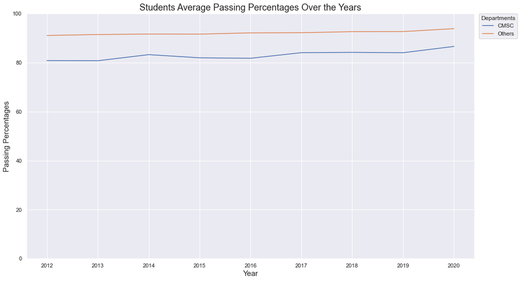

```python
# Set plot style.
plt.figure(figsize = (16, 9))
sns.set(style='darkgrid')

# Draw line plot.
sns.lineplot(data=averNum_df,
             x='year',
             y='passing_percentage',
             hue='department')

# Set labels.
plt.xlabel('Year',
           size=15)
plt.ylabel('Passing Percentages',
           size=15)
plt.ylim(0, 100)

# Set legend.
plt.legend(title='Departments',
           bbox_to_anchor=(1.01, 1),
           borderaxespad=0)

# Set title.
plt.title('Students Average Passing Percentages Over the Years',
          size=18)

# Show plot.
plt.show()
```

The above plot shows the almost 10% difference between the CMSC department and all other departments, so we can assume that computer science majors have more difficult classes. Furthermore, the graph displayed that the passing percentages has been slowly increasing over the years.

### 4.2.3 What are the top 10 highest average pass rate CMSC courses?

Now, we want to explore only the CMSC department from now on. We aimed this tutorial for computer science majors, so exploring the CMSC department is beneficial for the audience.

First, we would like to repeat our first scatter plot, but we will only plot the CMSC department.

|  | course | year | A+ | A | A- | B+ | B | B- | C+ | C | C- | D+ | D | D- | F | W | Other | number_of_grades | passing_grades | passing_percentage |
| --- | --- | --- | --- | --- | --- | --- | --- | --- | --- | --- | --- | --- | --- | --- | --- | --- | --- | --- | --- | --- |
| 0 | CMSC100 | 2012 | 15.0 | 4.0 | 1.0 | 1.0 | 1.0 | 0.0 | 0.0 | 1.0 | 0.0 | 0.0 | 0.0 | 0.0 | 0.0 | 0.0 | 0.0 | 23.0 | 23.0 | 100.00 |
| 1 | CMSC100 | 2013 | 7.0 | 11.0 | 2.0 | 2.0 | 6.0 | 3.0 | 1.0 | 3.0 | 2.0 | 0.0 | 1.0 | 0.0 | 1.0 | 7.0 | 0.0 | 46.0 | 37.0 | 80.43 |
| 2 | CMSC100 | 2014 | 19.0 | 9.0 | 1.0 | 2.0 | 0.0 | 3.0 | 0.0 | 0.0 | 1.0 | 0.0 | 0.0 | 0.0 | 1.0 | 1.0 | 0.0 | 37.0 | 35.0 | 94.59 |
| 3 | CMSC100 | 2015 | 20.0 | 5.0 | 5.0 | 5.0 | 3.0 | 1.0 | 3.0 | 1.0 | 0.0 | 0.0 | 0.0 | 0.0 | 3.0 | 1.0 | 0.0 | 47.0 | 43.0 | 91.49 |
| 4 | CMSC100 | 2016 | 17.0 | 6.0 | 2.0 | 3.0 | 2.0 | 1.0 | 2.0 | 0.0 | 1.0 | 1.0 | 1.0 | 0.0 | 2.0 | 0.0 | 0.0 | 38.0 | 34.0 | 89.47 |
| ... | ... | ... | ... | ... | ... | ... | ... | ... | ... | ... | ... | ... | ... | ... | ... | ... | ... | ... | ... | ... |
| 327 | CMSC456 | 2014 | 1.0 | 9.0 | 3.0 | 1.0 | 8.0 | 2.0 | 0.0 | 9.0 | 2.0 | 0.0 | 0.0 | 0.0 | 0.0 | 8.0 | 0.0 | 43.0 | 35.0 | 81.40 |
| 328 | CMSC456 | 2016 | 4.0 | 12.0 | 5.0 | 4.0 | 16.0 | 6.0 | 0.0 | 15.0 | 6.0 | 0.0 | 0.0 | 0.0 | 5.0 | 13.0 | 0.0 | 86.0 | 68.0 | 79.07 |
| 329 | CMSC457 | 2018 | 2.0 | 7.0 | 3.0 | 2.0 | 7.0 | 4.0 | 3.0 | 3.0 | 3.0 | 1.0 | 0.0 | 0.0 | 0.0 | 5.0 | 0.0 | 40.0 | 34.0 | 85.00 |
| 330 | CMSC457 | 2019 | 2.0 | 9.0 | 1.0 | 2.0 | 3.0 | 1.0 | 2.0 | 3.0 | 0.0 | 0.0 | 0.0 | 0.0 | 2.0 | 11.0 | 0.0 | 36.0 | 23.0 | 63.89 |
| 331 | CMSC457 | 2020 | 3.0 | 4.0 | 6.0 | 3.0 | 2.0 | 0.0 | 0.0 | 0.0 | 0.0 | 0.0 | 0.0 | 0.0 | 2.0 | 7.0 | 22.0 | 49.0 | 40.0 | 81.63 |

332 rows × 20 columns

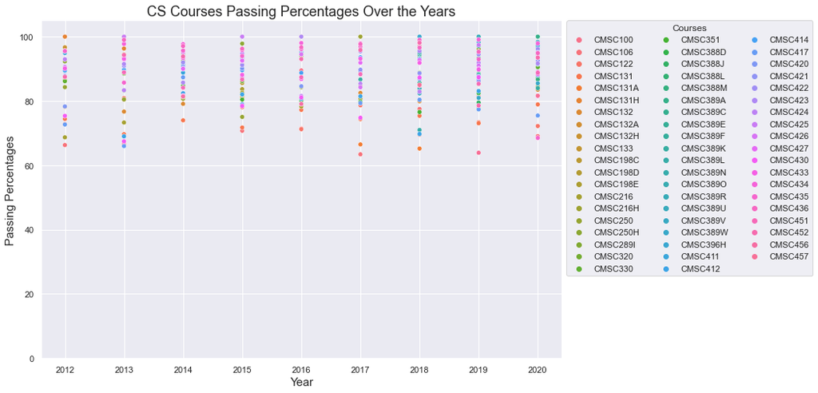

```python
# Class over the years.
cs_clss_over_year_df = cs_df.groupby(['course', 'year']).mean().reset_index()
display(cs_clss_over_year_df)

# Set plot size.
fig = plt.figure(figsize=(12, 8))

# Plot scatter plot.
sns.scatterplot(data=cs_clss_over_year_df,
                x='year',
                y='passing_percentage',
                hue='course')

# Set labels.
plt.xlabel('Year',
           size=15)
plt.ylabel('Passing Percentages',
           size=15)
plt.ylim(0, 105)

# Set legend.
plt.legend(title='Courses',
           bbox_to_anchor=(1.01, 1),
           borderaxespad=0,
           ncol=3)

# Set title.
plt.title('CS Courses Passing Percentages Over the Years',
          size=18)

# Show plot.
plt.show()
```

From the above plot, we can't see any patterns or trends, but we can say that the average passing percentage range is about 60% to 100%.

Since we do not really see a trend in the above scatter plot, let's create a bar plot to know which class has the highest average passing percentage of all time. This is useful for students who only care about classes with a high passing rate.

|  | course | A+ | A | A- | B+ | B | B- | C+ | C | C- | D+ | D | D- | F | W | Other | number_of_grades | passing_grades | passing_percentage |
| --- | --- | --- | --- | --- | --- | --- | --- | --- | --- | --- | --- | --- | --- | --- | --- | --- | --- | --- | --- |
| 0 | CMSC216H | 6.000000 | 6.333333 | 2.000000 | 3.333333 | 3.000000 | 1.000000 | 0.000000 | 0.666667 | 0.000000 | 0.000000 | 0.333333 | 0.000000 | 0.000000 | 0.000000 | 0.000000 | 22.666667 | 22.333333 | 98.716667 |
| 1 | CMSC389V | 13.500000 | 8.000000 | 3.000000 | 2.000000 | 0.500000 | 0.000000 | 0.000000 | 0.000000 | 0.000000 | 0.000000 | 0.000000 | 0.000000 | 0.500000 | 0.000000 | 4.000000 | 31.500000 | 31.000000 | 98.335000 |
| 2 | CMSC389A | 1.500000 | 15.000000 | 0.500000 | 1.000000 | 3.000000 | 0.000000 | 0.000000 | 0.500000 | 0.000000 | 0.000000 | 0.000000 | 0.000000 | 0.000000 | 0.500000 | 0.500000 | 22.500000 | 22.000000 | 98.275000 |
| 3 | CMSC131H | 5.500000 | 11.000000 | 2.000000 | 1.000000 | 2.000000 | 0.500000 | 0.000000 | 1.500000 | 0.500000 | 0.000000 | 0.000000 | 0.000000 | 0.500000 | 0.000000 | 0.000000 | 24.500000 | 24.000000 | 98.150000 |
| 4 | CMSC434 | 3.517241 | 17.413793 | 7.206897 | 4.310345 | 11.517241 | 2.448276 | 0.965517 | 2.275862 | 0.655172 | 0.034483 | 0.172414 | 0.103448 | 0.103448 | 0.655172 | 2.241379 | 53.620690 | 52.551724 | 97.798966 |
| 5 | CMSC425 | 4.454545 | 18.363636 | 10.636364 | 8.363636 | 8.545455 | 3.909091 | 2.000000 | 1.636364 | 0.545455 | 0.090909 | 0.090909 | 0.000000 | 0.272727 | 1.636364 | 2.818182 | 63.363636 | 61.272727 | 97.267273 |
| 6 | CMSC436 | 1.875000 | 29.250000 | 9.000000 | 10.875000 | 20.250000 | 6.062500 | 2.875000 | 5.875000 | 2.687500 | 0.000000 | 0.375000 | 0.000000 | 0.937500 | 2.375000 | 5.937500 | 98.375000 | 94.687500 | 96.773125 |
| 7 | CMSC250H | 2.444444 | 9.888889 | 2.111111 | 2.000000 | 4.444444 | 2.111111 | 0.666667 | 0.555556 | 0.222222 | 0.000000 | 0.222222 | 0.111111 | 0.333333 | 0.333333 | 0.000000 | 25.444444 | 24.444444 | 96.253333 |
| 8 | CMSC132H | 3.250000 | 5.500000 | 4.875000 | 2.625000 | 1.625000 | 2.250000 | 0.625000 | 0.500000 | 0.500000 | 0.000000 | 0.125000 | 0.125000 | 0.375000 | 0.250000 | 0.000000 | 22.625000 | 21.750000 | 95.812500 |
| 9 | CMSC388L | 5.500000 | 10.500000 | 1.000000 | 3.000000 | 2.000000 | 0.000000 | 0.500000 | 1.500000 | 0.000000 | 0.000000 | 0.500000 | 0.000000 | 1.000000 | 0.000000 | 4.500000 | 30.000000 | 28.500000 | 95.000000 |

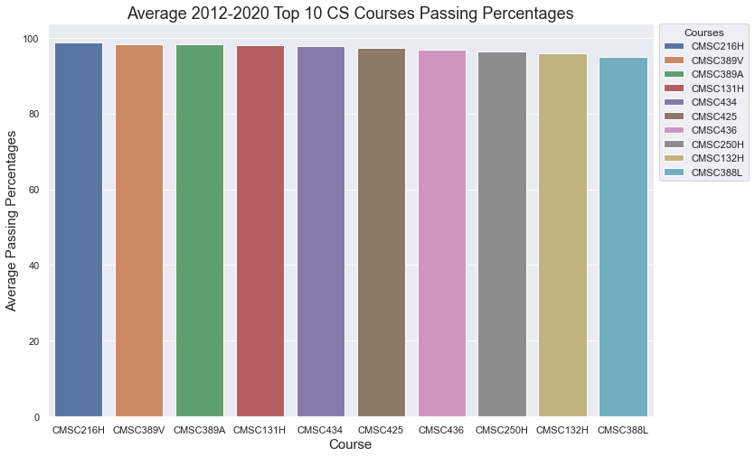

```python
# Top 10 CS class average of all the years.
cs_clss_df = cs_df.groupby(['course']).mean().nlargest(10, columns='passing_percentage').reset_index()
display(cs_clss_df)

# Set plot size.
fig = plt.figure(figsize=(12, 8))

# Plot bar plot.
sns.barplot(data=cs_clss_df,
            x='course',
            y='passing_percentage',
            hue='course',
            dodge=False)

# Set labels.
plt.xlabel('Course',
           size=15)
plt.ylabel('Average Passing Percentages',
           size=15)

# Set legend.
plt.legend(title='Courses',
           bbox_to_anchor=(1.01, 1),
           borderaxespad=0)

# Set title.
plt.title('Average 2012-2020 Top 10 CS Courses Passing Percentages',
          size=18)

# Show plot.
plt.show()
```

The bar plot above shows the top 10 classes with the highest passing rate. For computer science majors, we can say that taking the following courses would have a high passing rate:

- CMSC216H
- CMSC389V
- CMSC389A
- CMSC131H
- CMSC434
- CMSC425
- CMSC436
- CMSC250H
- CMSC132H
- CMSC388L

### 4.2.4 What are the top 10 highest average pass rate for CMSC professors?

Next, we would like to know which professors have the highest pass rate. Students who know which professors are the best may find this information useful. We want to present the average passing percentage for each professor over the years using a scatter plot.

|  | professor | year | A+ | A | A- | B+ | B | B- | C+ | C | C- | D+ | D | D- | F | W | Other | number_of_grades | passing_grades | passing_percentage |
| --- | --- | --- | --- | --- | --- | --- | --- | --- | --- | --- | --- | --- | --- | --- | --- | --- | --- | --- | --- | --- |
| 206 | Jeffrey Foster | 2012 | 2.5 | 9.500000 | 3.500000 | 1.500000 | 6.500000 | 0.000000 | 0.000 | 3.50 | 0.5 | 0.0 | 0.50 | 0.0 | 5.000000 | 3.500000 | 0.000000 | 36.500000 | 27.500000 | 75.375000 |
| 49 | Ashok Agrawala | 2012 | 5.0 | 3.500000 | 5.500000 | 3.000000 | 6.500000 | 2.000000 | 4.000 | 3.50 | 2.5 | 0.0 | 2.00 | 0.5 | 2.500000 | 2.500000 | 0.000000 | 43.000000 | 35.500000 | 82.200000 |
| 375 | Thomas Reinhardt | 2012 | 1.4 | 2.800000 | 2.800000 | 3.200000 | 4.600000 | 3.600000 | 3.000 | 4.60 | 2.0 | 0.4 | 1.20 | 0.2 | 1.400000 | 1.200000 | 0.000000 | 32.400000 | 28.000000 | 87.534000 |
| 57 | Atif Memon | 2012 | 3.0 | 10.000000 | 8.000000 | 2.000000 | 10.000000 | 8.000000 | 2.000 | 3.00 | 2.0 | 0.0 | 1.00 | 0.0 | 0.000000 | 1.000000 | 0.000000 | 50.000000 | 48.000000 | 96.000000 |
| 70 | Chau-Wen Tseng | 2012 | 1.5 | 3.375000 | 2.000000 | 1.875000 | 5.000000 | 2.125000 | 1.625 | 4.75 | 2.0 | 0.0 | 0.75 | 0.0 | 0.500000 | 0.875000 | 0.000000 | 26.375000 | 24.250000 | 91.947500 |
| ... | ... | ... | ... | ... | ... | ... | ... | ... | ... | ... | ... | ... | ... | ... | ... | ... | ... | ... | ... | ... |
| 374 | Thomas Goldstein | 2020 | 7.0 | 12.666667 | 1.555556 | 2.111111 | 0.888889 | 0.222222 | 0.000 | 0.00 | 0.0 | 0.0 | 0.00 | 0.0 | 0.111111 | 1.333333 | 4.333333 | 30.222222 | 28.777778 | 95.244444 |
| 161 | Hanan Samet | 2020 | 0.0 | 7.000000 | 0.000000 | 0.000000 | 10.000000 | 0.000000 | 0.000 | 10.00 | 0.0 | 0.0 | 4.00 | 0.0 | 4.000000 | 13.000000 | 0.000000 | 48.000000 | 27.000000 | 56.250000 |
| 170 | Hector Corrada Bravo | 2020 | 157.0 | 53.000000 | 15.000000 | 4.000000 | 4.000000 | 1.000000 | 0.000 | 0.00 | 0.0 | 0.0 | 0.00 | 0.0 | 2.000000 | 11.000000 | 50.000000 | 297.000000 | 284.000000 | 95.620000 |
| 137 | Evan Golub | 2020 | 3.0 | 10.800000 | 3.000000 | 5.200000 | 8.400000 | 2.800000 | 1.600 | 0.60 | 0.4 | 0.0 | 0.00 | 0.6 | 0.400000 | 0.400000 | 13.000000 | 50.200000 | 48.800000 | 97.216000 |
| 0 | A Shankar | 2020 | 0.5 | 4.250000 | 1.750000 | 0.750000 | 4.250000 | 1.250000 | 1.750 | 6.00 | 3.5 | 0.0 | 3.75 | 0.0 | 3.500000 | 5.500000 | 0.000000 | 36.750000 | 24.000000 | 65.292500 |

414 rows × 20 columns

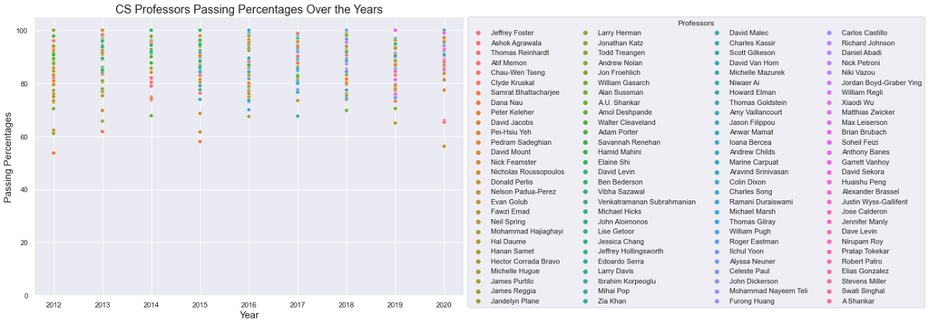

```python
# Professors over the years.
cs_prof_over_year_df = cs_df.groupby(['professor', 'year']).mean().reset_index()
cs_prof_over_year_df = cs_prof_over_year_df.sort_values(by='year')
display(cs_prof_over_year_df)

# Set plot size.
fig = plt.figure(figsize=(12, 8))

# Plot scatter plot.
sns.scatterplot(data=cs_prof_over_year_df,
                x='year',
                y='passing_percentage',
                hue='professor')

# Set labels.
plt.xlabel('Year',
           size=15)
plt.ylabel('Passing Percentages',
           size=15)
plt.ylim(0, 105)

# Set legend.
plt.legend(title='Professors',
           bbox_to_anchor=(1.01, 1),
           borderaxespad=0,
           ncol=4)

# Set title.
plt.title('CS Professors Passing Percentages Over the Years',
          size=18)

# Show plot.
plt.show()
```

From the scatter plot above, we can't see any clear patterns or trends between professors and time, but we can conclude that most professors give over a 60% pass rate. Additionally, from the above plot, we can say that there are inconsistencies with the names of professors being entered differently in the database.

Now, we want to know the top 10 professors of all time. It's easy to see the top 10 with a bar chart.

|  | professor | A+ | A | A- | B+ | B | B- | C+ | C | C- | D+ | D | D- | F | W | Other | number_of_grades | passing_grades | passing_percentage |
| --- | --- | --- | --- | --- | --- | --- | --- | --- | --- | --- | --- | --- | --- | --- | --- | --- | --- | --- | --- |
| 0 | Andrew Nolan | 15.000000 | 4.000000 | 1.000000 | 1.000000 | 1.0 | 0.000000 | 0.000000 | 1.000000 | 0.000000 | 0.000000 | 0.000000 | 0.0 | 0.000000 | 0.000000 | 0.000000 | 23.000000 | 23.000000 | 100.000000 |
| 1 | Huaishu Peng | 12.000000 | 61.000000 | 14.000000 | 4.000000 | 4.0 | 0.000000 | 1.000000 | 0.000000 | 0.000000 | 0.000000 | 0.000000 | 0.0 | 0.000000 | 0.000000 | 0.000000 | 96.000000 | 96.000000 | 100.000000 |
| 2 | Ibrahim Korpeoglu | 0.000000 | 2.000000 | 3.000000 | 1.000000 | 0.0 | 2.000000 | 0.000000 | 2.000000 | 1.000000 | 0.000000 | 0.000000 | 0.0 | 0.000000 | 0.000000 | 0.000000 | 11.000000 | 11.000000 | 100.000000 |
| 3 | Elias Gonzalez | 40.000000 | 29.000000 | 2.000000 | 1.000000 | 1.0 | 0.000000 | 0.000000 | 0.000000 | 1.000000 | 0.000000 | 0.000000 | 0.0 | 0.000000 | 1.000000 | 22.000000 | 97.000000 | 96.000000 | 98.970000 |
| 4 | Charles Song | 3.500000 | 11.500000 | 8.000000 | 15.000000 | 13.5 | 14.500000 | 8.000000 | 3.000000 | 2.500000 | 0.000000 | 0.000000 | 0.0 | 0.000000 | 1.000000 | 0.000000 | 80.500000 | 79.500000 | 98.835000 |
| 5 | Jon Froehlich | 1.666667 | 11.333333 | 9.333333 | 8.500000 | 9.0 | 3.166667 | 0.833333 | 0.333333 | 0.333333 | 0.166667 | 0.000000 | 0.0 | 0.166667 | 0.666667 | 0.166667 | 45.666667 | 44.666667 | 97.813333 |
| 6 | Scott Gilkeson | 9.000000 | 21.000000 | 4.250000 | 5.250000 | 1.5 | 0.500000 | 0.000000 | 0.750000 | 0.250000 | 0.000000 | 0.250000 | 0.0 | 0.000000 | 0.750000 | 2.000000 | 45.500000 | 44.500000 | 97.700000 |
| 7 | Edoardo Serra | 5.000000 | 10.000000 | 6.000000 | 6.000000 | 3.0 | 5.000000 | 2.000000 | 2.000000 | 1.000000 | 0.000000 | 0.000000 | 0.0 | 0.000000 | 1.000000 | 0.000000 | 41.000000 | 40.000000 | 97.560000 |
| 8 | Atif Memon | 3.833333 | 19.000000 | 3.833333 | 3.666667 | 8.0 | 3.333333 | 0.666667 | 3.833333 | 0.500000 | 0.000000 | 0.166667 | 0.0 | 0.500000 | 0.500000 | 0.000000 | 47.833333 | 46.666667 | 97.486667 |
| 9 | Soheil Feizi | 9.000000 | 24.000000 | 9.500000 | 8.500000 | 4.0 | 3.000000 | 1.500000 | 3.500000 | 0.000000 | 0.000000 | 0.000000 | 0.0 | 0.000000 | 2.000000 | 16.000000 | 81.000000 | 79.000000 | 97.205000 |

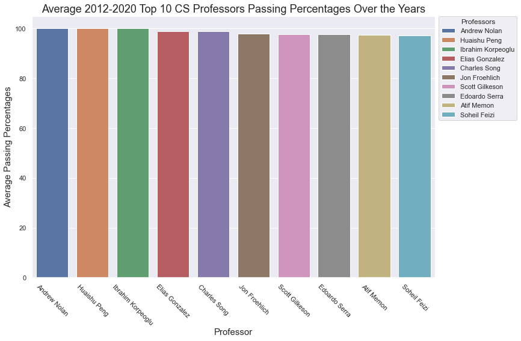

```python
# Top 10 CS professors average of all the years.
cs_prof_df = cs_df.groupby(['professor']).mean().nlargest(10, columns='passing_percentage').reset_index()
display(cs_prof_df)

# Set plot size.
fig = plt.figure(figsize=(12, 8))

# Plot bar plot.
sns.barplot(data=cs_prof_df,
            x='professor',
            y='passing_percentage',
            hue='professor',
            dodge=False)

# Set labels.
plt.xlabel('Professor',
           size=15)
plt.ylabel('Average Passing Percentages',
           size=15)
plt.xticks(rotation=315)

# Set legend.
plt.legend(title='Professors',
           bbox_to_anchor=(1.01, 1),
           borderaxespad=0)
# Set title.
plt.title('Average 2012-2020 Top 10 CS Professors Passing Percentages Over the Years',
          size=18)

# Show plot.
plt.show()
```

From the bar plot above, there are quite a few professors with almost a 100% pass rate. Those professors are:

- Andrew Nolan
- Huaishu Peng
- Ibrahim Korpeoglu
- Elias Gonzalez
- Charles Song
- Jon Froehlich
- Scott Gilkeson
- Edoardo Serra
- Atif Memon
- Soheil Feizi

If a student sees any of these 10 professors teaching a class, they should try to register as soon as possible. However, these professors could have taught only 2 semesters or may not be teaching anymore.

### 4.2.5 What are the top 10 highest average pass rate CMSC courses and professors?

The final metric that computer science may want to know is the highest passing classes with a certain professor. This information combines the above two conditions from earlier and gives more specific information. Again, we want to initially see how these two metrics interact with each other with a scatter plot of the average pass rate over 9 years.

|  | course | professor | year | A+ | A | A- | B+ | B | B- | C+ | ... | C- | D+ | D | D- | F | W | Other | number_of_grades | passing_grades | passing_percentage |
| --- | --- | --- | --- | --- | --- | --- | --- | --- | --- | --- | --- | --- | --- | --- | --- | --- | --- | --- | --- | --- | --- |
| 550 | CMSC435 | Atif Memon | 2012 | 3.000000 | 10.000000 | 8.000000 | 2.000000 | 10.000000 | 8.000000 | 2.0 | ... | 2.0 | 0.0 | 1.000000 | 0.000000 | 0.0 | 1.0 | 0.0 | 50.000000 | 48.000000 | 96.000 |
| 368 | CMSC417 | Samrat Bhattacharjee | 2012 | 3.000000 | 2.000000 | 0.000000 | 4.000000 | 1.000000 | 0.000000 | 2.0 | ... | 2.0 | 0.0 | 3.000000 | 0.000000 | 8.0 | 8.0 | 2.0 | 41.000000 | 22.000000 | 53.660 |
| 376 | CMSC420 | Hanan Samet | 2012 | 0.000000 | 7.000000 | 2.000000 | 0.000000 | 6.000000 | 0.000000 | 0.0 | ... | 2.0 | 0.0 | 4.000000 | 0.000000 | 2.0 | 8.0 | 0.0 | 36.000000 | 22.000000 | 61.110 |
| 389 | CMSC420 | Michelle Hugue | 2012 | 1.666667 | 5.333333 | 3.333333 | 1.333333 | 5.333333 | 7.333333 | 0.0 | ... | 4.0 | 0.0 | 0.666667 | 1.333333 | 1.0 | 3.0 | 1.0 | 41.333333 | 35.333333 | 84.020 |
| 42 | CMSC131 | Fawzi Emad | 2012 | 3.000000 | 4.000000 | 2.000000 | 0.000000 | 5.000000 | 2.000000 | 0.0 | ... | 2.5 | 0.0 | 1.500000 | 0.000000 | 5.0 | 3.5 | 0.0 | 35.000000 | 25.000000 | 71.665 |
| ... | ... | ... | ... | ... | ... | ... | ... | ... | ... | ... | ... | ... | ... | ... | ... | ... | ... | ... | ... | ... | ... |
| 429 | CMSC422 | James Reggia | 2020 | 1.000000 | 45.000000 | 5.000000 | 0.000000 | 7.000000 | 0.000000 | 0.0 | ... | 0.0 | 0.0 | 0.000000 | 0.000000 | 0.0 | 1.0 | 41.0 | 101.000000 | 100.000000 | 99.010 |
| 435 | CMSC422 | Ramani Duraiswami | 2020 | 6.000000 | 15.000000 | 18.000000 | 6.000000 | 15.000000 | 12.000000 | 9.0 | ... | 2.0 | 0.0 | 1.000000 | 0.000000 | 0.0 | 7.0 | 0.0 | 96.000000 | 88.000000 | 91.670 |
| 113 | CMSC133 | Nelson Padua-Perez | 2020 | 6.000000 | 1.000000 | 2.000000 | 1.000000 | 0.000000 | 0.000000 | 0.0 | ... | 0.0 | 0.0 | 0.000000 | 0.000000 | 0.0 | 0.0 | 2.0 | 12.000000 | 12.000000 | 100.000 |
| 264 | CMSC389E | Anwar Mamat | 2020 | 17.000000 | 7.000000 | 5.000000 | 0.000000 | 0.000000 | 0.000000 | 0.0 | ... | 0.0 | 0.0 | 0.000000 | 0.000000 | 0.0 | 1.0 | 0.0 | 30.000000 | 29.000000 | 96.670 |
| 609 | CMSC457 | Xiaodi Wu | 2020 | 3.000000 | 4.000000 | 6.000000 | 3.000000 | 2.000000 | 0.000000 | 0.0 | ... | 0.0 | 0.0 | 0.000000 | 0.000000 | 2.0 | 7.0 | 22.0 | 49.000000 | 40.000000 | 81.630 |

610 rows × 21 columns

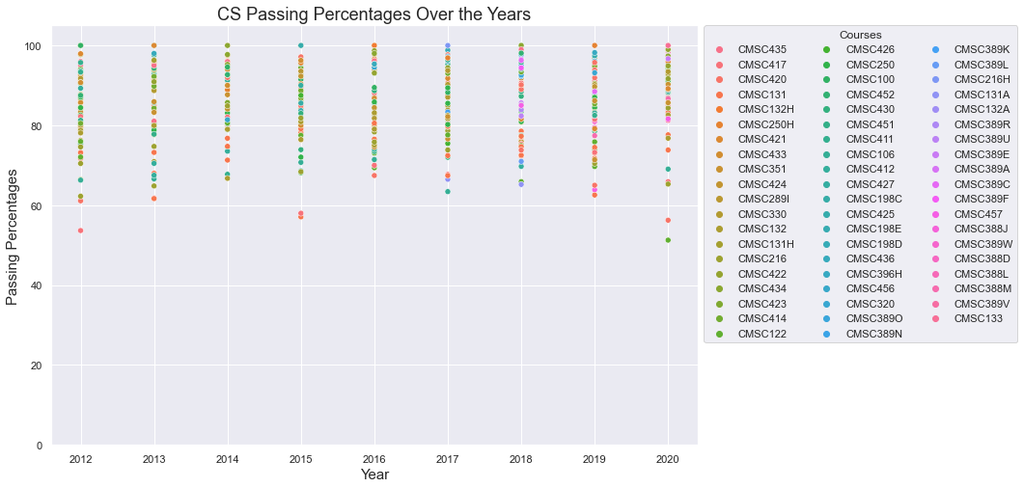

```python
# Class and Professor combined over the years.
cs_class_n_prof_over_year_df = cs_df.groupby(['course','professor', 'year']).mean().reset_index()
cs_class_n_prof_over_year_df = cs_class_n_prof_over_year_df.sort_values(by='year')
display(cs_class_n_prof_over_year_df)

# Set plot size.
fig = plt.figure(figsize=(12, 8))

# Plot scatter plot.
sns.scatterplot(data=cs_class_n_prof_over_year_df,
                x='year',
                y='passing_percentage',
                hue='course')

# Set labels.
plt.xlabel('Year',
           size=15)
plt.ylabel('Passing Percentages',
           size=15)
plt.ylim(0, 105)

# Set legend.
plt.legend(title='Courses',
           bbox_to_anchor=(1.01, 1),
           borderaxespad=0,
           ncol=3)

# Set title.
plt.title('CS Passing Percentages Over the Years',
          size=18)

# Show plot.
plt.show()
```

Again, it isn't easy to extract information from this scatter plot, but it closely resembles the class-only scatter plot from earlier. We want to know which professor and their class have the highest pass rate of all time using a bar plot.

|  | course | professor | A+ | A | A- | B+ | B | B- | C+ | C | C- | D+ | D | D- | F | W | Other | number_of_grades | passing_grades | passing_percentage |
| --- | --- | --- | --- | --- | --- | --- | --- | --- | --- | --- | --- | --- | --- | --- | --- | --- | --- | --- | --- | --- |
| 0 | CMSC100 | Andrew Nolan | 15.0 | 4.0 | 1.0 | 1.0 | 1.0 | 0.0 | 0.0 | 1.0 | 0.0 | 0.0 | 0.0 | 0.0 | 0.0 | 0.0 | 0.0 | 23.0 | 23.0 | 100.0 |
| 1 | CMSC131H | Evan Golub | 5.0 | 10.0 | 2.0 | 2.0 | 1.0 | 0.0 | 0.0 | 2.0 | 0.0 | 0.0 | 0.0 | 0.0 | 0.0 | 0.0 | 0.0 | 22.0 | 22.0 | 100.0 |
| 2 | CMSC133 | Nelson Padua-Perez | 6.0 | 1.0 | 2.0 | 1.0 | 0.0 | 0.0 | 0.0 | 0.0 | 0.0 | 0.0 | 0.0 | 0.0 | 0.0 | 0.0 | 2.0 | 12.0 | 12.0 | 100.0 |
| 3 | CMSC389A | Neil Spring | 3.0 | 9.0 | 1.0 | 2.0 | 1.0 | 0.0 | 0.0 | 0.0 | 0.0 | 0.0 | 0.0 | 0.0 | 0.0 | 0.0 | 0.0 | 16.0 | 16.0 | 100.0 |
| 4 | CMSC396H | Atif Memon | 0.0 | 23.0 | 0.0 | 0.0 | 0.0 | 0.0 | 0.0 | 0.0 | 0.0 | 0.0 | 0.0 | 0.0 | 0.0 | 0.0 | 0.0 | 23.0 | 23.0 | 100.0 |
| 5 | CMSC396H | Vibha Sazawal | 9.0 | 12.0 | 0.0 | 1.0 | 0.0 | 0.0 | 0.0 | 0.0 | 0.0 | 0.0 | 0.0 | 0.0 | 0.0 | 0.0 | 0.0 | 22.0 | 22.0 | 100.0 |
| 6 | CMSC417 | Ibrahim Korpeoglu | 0.0 | 2.0 | 3.0 | 1.0 | 0.0 | 2.0 | 0.0 | 2.0 | 1.0 | 0.0 | 0.0 | 0.0 | 0.0 | 0.0 | 0.0 | 11.0 | 11.0 | 100.0 |
| 7 | CMSC434 | Huaishu Peng | 12.0 | 61.0 | 14.0 | 4.0 | 4.0 | 0.0 | 1.0 | 0.0 | 0.0 | 0.0 | 0.0 | 0.0 | 0.0 | 0.0 | 0.0 | 96.0 | 96.0 | 100.0 |
| 8 | CMSC434 | Vibha Sazawal | 1.8 | 28.0 | 12.8 | 0.0 | 19.0 | 2.6 | 0.0 | 2.2 | 0.6 | 0.0 | 0.0 | 0.0 | 0.0 | 0.0 | 0.0 | 67.0 | 67.0 | 100.0 |
| 9 | CMSC436 | Atif Memon | 5.5 | 31.0 | 2.5 | 5.0 | 13.0 | 2.0 | 0.5 | 6.0 | 0.5 | 0.0 | 0.0 | 0.0 | 0.5 | 0.0 | 0.0 | 66.5 | 66.0 | 99.4 |

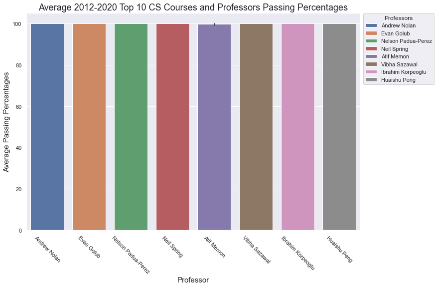

```python
# Top 10 CS courses and professors average of all the years
cs_clss_n_prof_df = cs_df.groupby(['course', 'professor']).mean().nlargest(10, columns='passing_percentage').reset_index()
display(cs_clss_n_prof_df)

# Set plot size.
fig = plt.figure(figsize=(12, 8))

# # Plot bar plot.
sns.barplot(data=cs_clss_n_prof_df,
            x='professor',
            y='passing_percentage',
            hue='professor',
            dodge=False)

# Set labels.
plt.xlabel('Professor',
           size=15)
plt.ylabel('Average Passing Percentages',
           size=15)
plt.xticks(rotation=315)

# Set legend.
plt.legend(title='Professors',
           bbox_to_anchor=(1.01, 1),
           borderaxespad=0)

# Set title.
plt.title('Average 2012-2020 Top 10 CS Courses and Professors Passing Percentages',
          size=18)

# Show plot.
plt.show()
```

We can see that the top 10 courses and their professor is similar to the top 10 professor list. The list is dominated by courses having a 100% pass rate. These are the following courses one should take if the professor is teaching it:

- CMSC100 Andrew Nolan
- CMSC131H Evan Golub
- CMSC133 Nelson Padua-Perez
- CMSC389A Neil Spring
- CMSC396H Atif Memon
- CMSC396H Vibha Sazawal
- CMSC417 Ibrahim Korpeoglu
- CMSC434 Huaishu Peng
- CMSC434 Vibha Sazawal
- CMSC436 Atif Memon

This list suffers the same problems as before. These courses may not be taught anymore, and the professor may have left the school.

### 4.2.6 What are the top 10 highest average pass rate departments for Upper Level Concentration?

Choosing classes for your major is already a pain; however, as a CS student, you also need to complete the Upper Level Concentration (ULC) courses in order to graduate. Selecting your ULC courses are like choosing a minor, which is just bad when it's not your main interest. We will curate the data so that it shows departments that have courses that have been there from the beginning.

|  | department | A+ | A | A- | B+ | B | B- | C+ | C | C- | D+ | D | D- | F | W | Other | number_of_grades | passing_grades | passing_percentage |
| --- | --- | --- | --- | --- | --- | --- | --- | --- | --- | --- | --- | --- | --- | --- | --- | --- | --- | --- | --- |
| 0 | BIPH | 0.230769 | 2.846154 | 0.769231 | 0.307692 | 0.384615 | 0.000000 | 0.000000 | 0.000000 | 0.000000 | 0.000000 | 0.000000 | 0.0 | 0.000000 | 0.000000 | 1.307692 | 5.846154 | 5.846154 | 100.000000 |
| 1 | MOCB | 5.000000 | 4.500000 | 0.000000 | 0.500000 | 0.000000 | 0.000000 | 0.000000 | 0.000000 | 0.000000 | 0.000000 | 0.000000 | 0.0 | 0.000000 | 0.000000 | 0.000000 | 10.000000 | 10.000000 | 100.000000 |
| 2 | VMSC | 0.931034 | 4.827586 | 0.413793 | 0.172414 | 0.103448 | 0.000000 | 0.000000 | 0.000000 | 0.000000 | 0.000000 | 0.000000 | 0.0 | 0.000000 | 0.000000 | 0.172414 | 6.620690 | 6.620690 | 100.000000 |
| 3 | CPSF | 0.000000 | 75.846154 | 4.615385 | 1.923077 | 1.461538 | 0.692308 | 0.153846 | 0.230769 | 0.076923 | 0.000000 | 0.000000 | 0.0 | 0.000000 | 0.153846 | 0.076923 | 85.230769 | 85.076923 | 99.825385 |
| 4 | ENCO | 0.000000 | 0.000000 | 0.000000 | 0.000000 | 0.000000 | 0.000000 | 0.000000 | 0.000000 | 0.000000 | 0.000000 | 0.000000 | 0.0 | 0.000000 | 0.166667 | 86.444444 | 86.611111 | 86.444444 | 99.818333 |
| 5 | FGSM | 4.280000 | 16.100000 | 4.040000 | 1.760000 | 1.160000 | 0.320000 | 0.060000 | 0.060000 | 0.000000 | 0.000000 | 0.000000 | 0.0 | 0.000000 | 0.140000 | 1.060000 | 28.980000 | 28.840000 | 99.392200 |
| 6 | PEER | 5.044444 | 3.355556 | 0.422222 | 0.133333 | 0.155556 | 0.044444 | 0.066667 | 0.000000 | 0.000000 | 0.022222 | 0.000000 | 0.0 | 0.000000 | 0.044444 | 0.022222 | 9.311111 | 9.244444 | 99.335111 |
| 7 | HLSC | 8.459770 | 9.206897 | 4.643678 | 2.195402 | 1.781609 | 0.459770 | 0.149425 | 0.034483 | 0.011494 | 0.011494 | 0.011494 | 0.0 | 0.011494 | 0.114943 | 0.091954 | 27.183908 | 27.034483 | 99.150115 |
| 8 | GEMS | 3.879880 | 7.140140 | 0.463463 | 0.147147 | 0.100100 | 0.025025 | 0.004004 | 0.008008 | 0.004004 | 0.001001 | 0.002002 | 0.0 | 0.003003 | 0.091091 | 0.040040 | 11.908909 | 11.811812 | 99.140591 |
| 9 | HACS | 5.657895 | 9.986842 | 2.894737 | 0.789474 | 0.664474 | 0.250000 | 0.065789 | 0.118421 | 0.019737 | 0.000000 | 0.000000 | 0.0 | 0.013158 | 0.197368 | 0.256579 | 20.914474 | 20.703947 | 99.038882 |

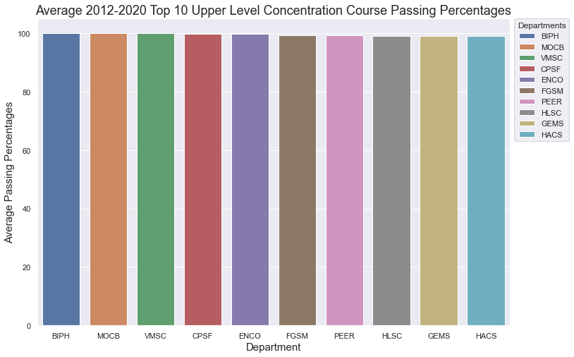

```python
# Get the top 10 passing from the original of each year.
dpt_over_year_df = df_averNum_stud.groupby(['department']).mean().nlargest(10, columns='passing_percentage').reset_index()
display(dpt_over_year_df)

# Set plot size.
fig = plt.figure(figsize=(12, 8))

# Plot scatter plot.
sns.barplot(data=dpt_over_year_df,
            x='department',
            y='passing_percentage',
            hue='department',
            dodge=False)

# Set labels.
plt.xlabel('Department',
           size=15)
plt.ylabel('Average Passing Percentages',
           size=15)

# Set legend.
plt.legend(title='Departments',
           bbox_to_anchor=(1.01, 1),
           borderaxespad=0)

# Set title.
plt.title('Average 2012-2020 Top 10 Upper Level Concentration Course Passing Percentages',
          size=18)

# Show plot.
plt.show()
```

The bar plot shows top 10 departments passing rates other than the CMSC department. If a computer science wants to choose an upper level concentration that isn't too difficult, they should look into these departments and see if they have classes available:

- BIPH
- MOCB
- VMSC
- CPSF
- ENCO
- FGSM
- PEER
- HLSC
- GEMS
- HACS

As with our previous graphs, we are looking at all historical data from 2012 to now (2020). These departments may not exist anymore.

### 4.2.7 What professors should computer science majors choose for their required courses?

For this section, we want to make recommendations for computer science majors and their required classes. The list of required classes are taken from the [Degree Requirements](https://undergrad.cs.umd.edu/degree-requirements-cs-major) page. Those classes are:

- CMSC131 Object-Oriented Programming I **or**
- CMSC133 Object-Oriented Programming I Beyond Fun
- CMSC132 Object-Oriented Programming II
- CMSC216 Introduction to Computer Systems
- CMSC250 Discrete Structures
- CMSC330 Organization of Programming Languages
- CMSC351 Algorithms

"Best professor" is defined as highest pass rate for that course. We also want to make sure to recommend professors that are still working, so our recommendations will be from 2018 to 2020.

```python
# Create course list.
course_list = ['CMSC131', 'CMSC133', 'CMSC132', 'CMSC216', 'CMSC250', 'CMSC330', 'CMSC351']

# Filter DataFrame for courses and years.
rec_df = cs_df[cs_df['course'].isin(course_list)]
rec_df = rec_df[rec_df['year'] >= '2018']

# Print DataFrame.
rec_df
```

|  | course | section | professor | semester | A+ | A | A- | B+ | B | B- | ... | D | D- | F | W | Other | number_of_grades | passing_grades | passing_percentage | year | department |
| --- | --- | --- | --- | --- | --- | --- | --- | --- | --- | --- | --- | --- | --- | --- | --- | --- | --- | --- | --- | --- | --- |
| 26928 | CMSC131 | 0201 | Fawzi Emad | 202008 | 2 | 4 | 1 | 2 | 2 | 3 | ... | 0 | 0 | 2 | 4 | 0 | 23 | 16 | 69.57 | 2020 | CMSC |
| 26929 | CMSC131 | 0202 | Fawzi Emad | 202008 | 1 | 5 | 2 | 4 | 2 | 0 | ... | 1 | 0 | 2 | 2 | 0 | 24 | 19 | 79.17 | 2020 | CMSC |
| 26930 | CMSC131 | 0203 | Fawzi Emad | 202008 | 2 | 1 | 1 | 0 | 0 | 0 | ... | 2 | 2 | 0 | 6 | 0 | 25 | 14 | 56.00 | 2020 | CMSC |
| 26931 | CMSC131 | 0204 | Fawzi Emad | 202008 | 2 | 7 | 2 | 4 | 2 | 2 | ... | 0 | 1 | 0 | 5 | 0 | 32 | 26 | 81.25 | 2020 | CMSC |
| 26932 | CMSC131 | 0205 | Fawzi Emad | 202008 | 1 | 6 | 1 | 2 | 7 | 2 | ... | 1 | 0 | 3 | 1 | 0 | 31 | 26 | 83.87 | 2020 | CMSC |
| ... | ... | ... | ... | ... | ... | ... | ... | ... | ... | ... | ... | ... | ... | ... | ... | ... | ... | ... | ... | ... | ... |
| 28349 | CMSC351 | 0101 | Mohammad Nayeem Teli | 201808 | 0 | 6 | 13 | 11 | 15 | 21 | ... | 5 | 3 | 5 | 10 | 0 | 141 | 108 | 76.60 | 2018 | CMSC |
| 28350 | CMSC351 | 0101 | Clyde Kruskal | 201801 | 1 | 3 | 9 | 8 | 10 | 18 | ... | 20 | 0 | 5 | 11 | 0 | 135 | 99 | 73.33 | 2018 | CMSC |
| 28351 | CMSC351 | 0201 | Clyde Kruskal | 201801 | 3 | 6 | 7 | 4 | 6 | 20 | ... | 15 | 0 | 5 | 13 | 0 | 135 | 102 | 75.56 | 2018 | CMSC |
| 28352 | CMSC351 | 0301 | Evan Golub | 201801 | 7 | 32 | 6 | 0 | 28 | 6 | ... | 5 | 4 | 9 | 10 | 0 | 135 | 107 | 79.26 | 2018 | CMSC |
| 28353 | CMSC351 | 0401 | Evan Golub | 201801 | 8 | 18 | 2 | 3 | 22 | 12 | ... | 4 | 6 | 15 | 9 | 0 | 134 | 100 | 74.63 | 2018 | CMSC |

630 rows × 24 columns

We ended up with **630** sections. We will get the highest average pass rate of each course.

```python
# Calculate highest pass rate for each course.
rec_df = rec_df.groupby(['course', 'professor']).mean().reset_index()
rec_df = rec_df.groupby(['course']).max().reset_index()

# Print DataFrame.
rec_df
```

|  | course | professor | A+ | A | A- | B+ | B | B- | C+ | C | C- | D+ | D | D- | F | W | Other | number_of_grades | passing_grades | passing_percentage |
| --- | --- | --- | --- | --- | --- | --- | --- | --- | --- | --- | --- | --- | --- | --- | --- | --- | --- | --- | --- | --- |
| 0 | CMSC131 | Roger Eastman | 7.657895 | 8.117647 | 4.368421 | 3.333333 | 6.000000 | 3.666667 | 3.000000 | 5.333333 | 1.631579 | 0.571429 | 2.666667 | 0.705882 | 3.705882 | 4.285714 | 1.894737 | 39.333333 | 31.000000 | 82.598158 |
| 1 | CMSC132 | Pedram Sadeghian | 4.270833 | 5.171429 | 4.350000 | 3.350000 | 7.057143 | 3.100000 | 2.250000 | 4.428571 | 1.950000 | 0.363636 | 1.628571 | 0.142857 | 2.450000 | 3.125000 | 12.136364 | 35.500000 | 31.727273 | 89.410909 |
| 2 | CMSC133 | Swati Singhal | 6.000000 | 1.000000 | 2.000000 | 3.000000 | 3.000000 | 0.000000 | 1.000000 | 0.000000 | 0.000000 | 0.000000 | 0.000000 | 0.000000 | 1.000000 | 2.000000 | 2.000000 | 16.000000 | 13.000000 | 100.000000 |
| 3 | CMSC216 | Pedram Sadeghian | 3.000000 | 6.208333 | 4.550000 | 5.600000 | 7.395833 | 3.800000 | 5.000000 | 6.000000 | 3.500000 | 0.000000 | 3.750000 | 0.285714 | 3.500000 | 5.500000 | 20.666667 | 36.750000 | 33.550000 | 93.013500 |
| 4 | CMSC250 | Roger Eastman | 3.000000 | 5.250000 | 5.333333 | 5.375000 | 10.375000 | 7.000000 | 4.333333 | 6.666667 | 4.666667 | 1.666667 | 2.533333 | 0.750000 | 1.750000 | 3.000000 | 6.038462 | 46.666667 | 40.000000 | 91.110000 |
| 5 | CMSC330 | Thomas Gilray | 4.333333 | 8.000000 | 2.500000 | 5.125000 | 11.000000 | 2.333333 | 3.333333 | 6.666667 | 3.000000 | 0.055556 | 2.000000 | 0.000000 | 1.055556 | 3.000000 | 4.733333 | 35.750000 | 32.500000 | 94.120000 |
| 6 | CMSC351 | Mohammad Nayeem Teli | 7.500000 | 25.000000 | 11.142857 | 15.714286 | 25.000000 | 20.714286 | 19.428571 | 16.000000 | 14.500000 | 7.428571 | 17.250000 | 5.000000 | 12.000000 | 11.166667 | 30.142857 | 179.000000 | 152.857143 | 84.351429 |

What a high pass rate! Look for these professors if you need to take these classes.

## 5. Hypothesis Testing and Machine Learning

### 5.1 What will the average passing percentage be for the CMSC department in 2021?

We know so far that the pass rates for the CMSC department has been increasing over the year. What we don't know is how much and what the percentage might be in 2021. We will make some predictions and find the answer to those questions with a linear regression model in the end of 5.1.

First, let's look at the trend of students passing percentages over the year with a violinplot.

|  | course | section | professor | semester | A+ | A | A- | B+ | B | B- | ... | D | D- | F | W | Other | number_of_grades | passing_grades | passing_percentage | year | department |
| --- | --- | --- | --- | --- | --- | --- | --- | --- | --- | --- | --- | --- | --- | --- | --- | --- | --- | --- | --- | --- | --- |
| 27822 | CMSC216 | 0103 | Neil Spring | 201208 | 3 | 2 | 1 | 0 | 2 | 2 | ... | 0 | 2 | 1 | 7 | 0 | 23 | 12 | 52.17 | 2012 | CMSC |
| 28332 | CMSC330 | 0203 | Chau-Wen Tseng | 201201 | 3 | 3 | 1 | 2 | 5 | 4 | ... | 0 | 0 | 1 | 0 | 0 | 26 | 25 | 96.15 | 2012 | CMSC |
| 28331 | CMSC330 | 0202 | Chau-Wen Tseng | 201201 | 0 | 4 | 0 | 0 | 7 | 2 | ... | 1 | 0 | 0 | 1 | 0 | 25 | 23 | 92.00 | 2012 | CMSC |
| 28330 | CMSC330 | 0201 | Chau-Wen Tseng | 201201 | 1 | 2 | 1 | 2 | 8 | 2 | ... | 1 | 0 | 0 | 1 | 0 | 27 | 25 | 92.59 | 2012 | CMSC |
| 28819 | CMSC433 | 0101 | Pei-Hsiu Yeh | 201201 | 0 | 19 | 0 | 0 | 10 | 0 | ... | 0 | 0 | 1 | 2 | 2 | 41 | 38 | 92.68 | 2012 | CMSC |
| ... | ... | ... | ... | ... | ... | ... | ... | ... | ... | ... | ... | ... | ... | ... | ... | ... | ... | ... | ... | ... | ... |
| 27299 | CMSC132 | 0305 | Fawzi Emad | 202001 | 0 | 3 | 1 | 2 | 4 | 1 | ... | 0 | 0 | 1 | 3 | 21 | 36 | 32 | 88.89 | 2020 | CMSC |
| 27300 | CMSC132 | 0306 | Fawzi Emad | 202001 | 1 | 2 | 3 | 3 | 0 | 1 | ... | 0 | 0 | 2 | 0 | 22 | 35 | 33 | 94.29 | 2020 | CMSC |
| 27301 | CMSC132 | 0307 | Fawzi Emad | 202001 | 3 | 5 | 1 | 3 | 2 | 2 | ... | 0 | 0 | 1 | 1 | 17 | 35 | 33 | 94.29 | 2020 | CMSC |
| 27303 | CMSC132 | 0401 | Fawzi Emad | 202001 | 1 | 2 | 5 | 2 | 1 | 0 | ... | 0 | 0 | 2 | 0 | 21 | 35 | 33 | 94.29 | 2020 | CMSC |
| 28129 | CMSC330 | 0107 | Anwar Mamat | 202001 | 1 | 0 | 1 | 5 | 0 | 2 | ... | 0 | 0 | 0 | 2 | 28 | 40 | 38 | 95.00 | 2020 | CMSC |

2045 rows × 24 columns

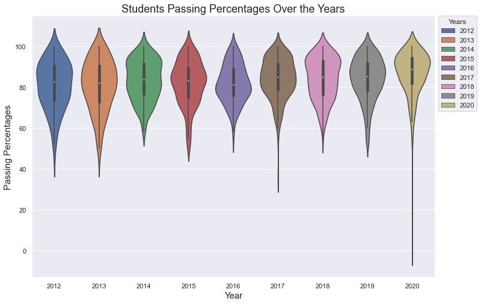

```python
# Sort dataframe by year.
cs_df = cs_df.sort_values(by='year')
display(cs_df)

# Set plot size.
fig = plt.figure(figsize=(12, 8))

# Plot scatter plot.
sns.violinplot(data=cs_df,
               x='year',
               y='passing_percentage',
               hue='year',
               dodge=False)

# Set labels.
plt.xlabel('Year',
           size=15)
plt.ylabel('Passing Percentages',
           size=15)

# Set legend.
plt.legend(title='Years',
           bbox_to_anchor=(1.01, 1),
           borderaxespad=0)

# Set title.
plt.title('Students Passing Percentages Over the Years',
          size=18)

# Show plot.
plt.show()
```

In the violin plot above, it looks like the median pass rate is increasing over time. We can say there is an increasing general trend over time, close to linear. We want to take a deep look at the distribution of each violin using histograms to determine if they're bimodal, unimodal, skewed, or symmetric.

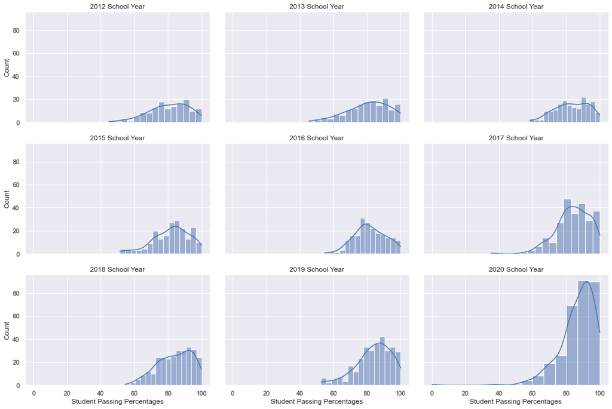

```python
# Plot histograms for students passing percentages for individual years.
stud_pass_pctg = sns.FacetGrid(data=cs_df,
                               col='year',
                               col_wrap=3)
stud_pass_pctg.map(sns.histplot,
                   'passing_percentage',
                   bins=15,
                   kde=True)

# Set the size of the plots and the labels.
stud_pass_pctg.fig.set_size_inches(15, 10)
stud_pass_pctg.set_axis_labels('Student Passing Percentages',
                               'Count')

# Create and save the xticks in years list.
years = []
for i in range(2012, 2021):
    years.append(i)

# Rename the titles of each subplots.
for ax, title in zip(stud_pass_pctg.axes.flat, years):
    ax.set_title(str(title) + ' School Year')

# Display the plot.
plt.show()
```

In the above histograms, we can see over the years that the distributions are all left-skewed. In other words, most of the students have a high passing rate since 2012. In addition, all the distributions are unimodal with one peak. What was interesting about the above graphs is that outliers are shown during 2017 and 2020. Thus, let's dive deeper to find the reason why.

```python
# Find outliers.
display(cs_df[cs_df['passing_percentage'] <= 40])
```

|  | course | section | professor | semester | A+ | A | A- | B+ | B | B- | ... | D | D- | F | W | Other | number_of_grades | passing_grades | passing_percentage | year | department |
| --- | --- | --- | --- | --- | --- | --- | --- | --- | --- | --- | --- | --- | --- | --- | --- | --- | --- | --- | --- | --- | --- |
| 27117 | CMSC131 | 0407 | Thomas Reinhardt | 201701 | 0 | 1 | 0 | 2 | 1 | 0 | ... | 1 | 2 | 4 | 4 | 0 | 17 | 6 | 35.29 | 2017 | CMSC |
| 26935 | CMSC131 | 0208 | Fawzi Emad | 202008 | 0 | 0 | 1 | 1 | 1 | 0 | ... | 0 | 0 | 2 | 3 | 0 | 8 | 3 | 37.50 | 2020 | CMSC |
| 28850 | CMSC435 | 0201 | NaN | 202008 | 0 | 0 | 0 | 0 | 0 | 0 | ... | 0 | 0 | 0 | 7 | 0 | 7 | 0 | 0.00 | 2020 | CMSC |

3 rows × 24 columns

In 2017, the CMSC131 class taught by Thomas Reinhardt had many failures and dropouts. It may have been the professor's first time teaching the course, or the students were not motivated enough. We cannot conclude what exactly happened, but there was a low pass rate of 35%.

In 2020, the same class CMSC131 taught by Fawzi Emad had similar issues with their pass rate of 38%. We cannot say exactly what happened, but we can say that CMSC131 might be a difficult class.

Now, we want to repeat the average pass rate over the years with a line plot but only with the CMSC department. We want to confirm that our assumptions about the pass rate increasing over time is a good observation.

|  | year | A+ | A | A- | B+ | B | B- | C+ | C | C- | D+ | D | D- | F | W | Other | number_of_grades | passing_grades | passing_percentage |
| --- | --- | --- | --- | --- | --- | --- | --- | --- | --- | --- | --- | --- | --- | --- | --- | --- | --- | --- | --- |
| 0 | 2012 | 1.671329 | 5.447552 | 2.447552 | 2.139860 | 5.951049 | 2.797203 | 1.783217 | 4.496503 | 2.132867 | 0.258741 | 1.636364 | 0.244755 | 1.818182 | 2.720280 | 0.118881 | 35.664336 | 28.986014 | 80.814196 |
| 1 | 2013 | 1.981481 | 5.246914 | 2.858025 | 2.481481 | 6.191358 | 2.820988 | 1.808642 | 3.765432 | 1.845679 | 0.302469 | 1.450617 | 0.246914 | 1.679012 | 2.858025 | 0.345679 | 35.882716 | 29.345679 | 80.750123 |
| 2 | 2014 | 1.988764 | 5.786517 | 3.151685 | 2.617978 | 6.528090 | 2.921348 | 1.960674 | 3.921348 | 2.117978 | 0.162921 | 1.797753 | 0.297753 | 1.488764 | 2.207865 | 0.129213 | 37.078652 | 31.123596 | 83.236966 |
| 3 | 2015 | 2.330000 | 5.965000 | 2.840000 | 3.285000 | 6.900000 | 2.995000 | 2.505000 | 3.905000 | 2.370000 | 0.170000 | 1.890000 | 0.265000 | 2.205000 | 2.625000 | 0.660000 | 40.910000 | 33.755000 | 81.946850 |
| 4 | 2016 | 2.485437 | 6.820388 | 3.567961 | 4.165049 | 6.946602 | 3.766990 | 2.878641 | 4.349515 | 2.883495 | 0.194175 | 2.019417 | 0.378641 | 2.092233 | 3.320388 | 0.140777 | 46.009709 | 38.004854 | 81.750097 |
| 5 | 2017 | 2.611765 | 7.207843 | 3.862745 | 3.964706 | 6.741176 | 3.713725 | 2.972549 | 3.992157 | 2.623529 | 0.207843 | 1.949020 | 0.231373 | 1.678431 | 2.564706 | 0.117647 | 44.439216 | 37.807843 | 84.032000 |
| 6 | 2018 | 3.134276 | 7.438163 | 4.597173 | 4.374558 | 6.968198 | 3.968198 | 3.215548 | 3.971731 | 2.445230 | 0.296820 | 1.558304 | 0.303887 | 1.855124 | 3.183746 | 0.151943 | 47.462898 | 40.265018 | 84.169470 |
| 7 | 2019 | 3.412338 | 7.035714 | 4.246753 | 4.899351 | 7.032468 | 3.837662 | 3.305195 | 3.899351 | 2.305195 | 0.353896 | 1.646104 | 0.204545 | 1.899351 | 2.724026 | 0.230519 | 47.032468 | 40.204545 | 84.017240 |
| 8 | 2020 | 5.393548 | 8.080645 | 3.890323 | 3.648387 | 4.554839 | 1.996774 | 1.509677 | 1.696774 | 0.793548 | 0.148387 | 0.561290 | 0.064516 | 1.409677 | 3.203226 | 11.029032 | 47.980645 | 42.593548 | 86.587290 |

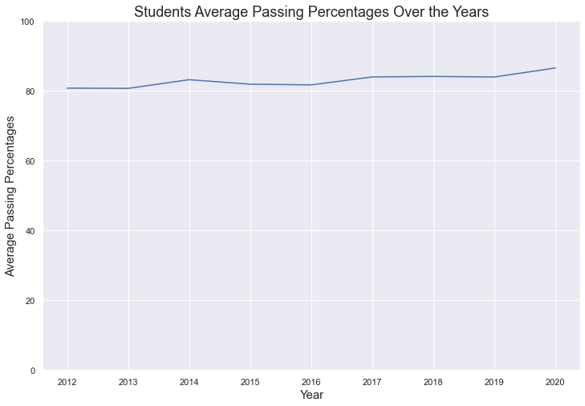

```python
# Create new dataframe with average passing percentages.
avg_cs_df = cs_df.groupby('year').mean().reset_index()
display(avg_cs_df)

# Set plot size.
fig = plt.figure(figsize=(12, 8))

# Create line plot.
sns.lineplot(data=avg_cs_df,
             x='year',
             y='passing_percentage')

# Set labels.
plt.xlabel('Year',
           size=15)
plt.ylabel('Average Passing Percentages',
           size=15)
plt.ylim(0, 100)

# Set title.
plt.title('Students Average Passing Percentages Over the Years',
          size=18)

# Show plot.
plt.show()
```

From the line plot above, there is a positive correlation with the pass rate over the years. We want to see the relationship between year and passing percentage, so we will use the scikit-learn module and calculate the linear regression model. We will plot the linear regression on top of a scatter plot.

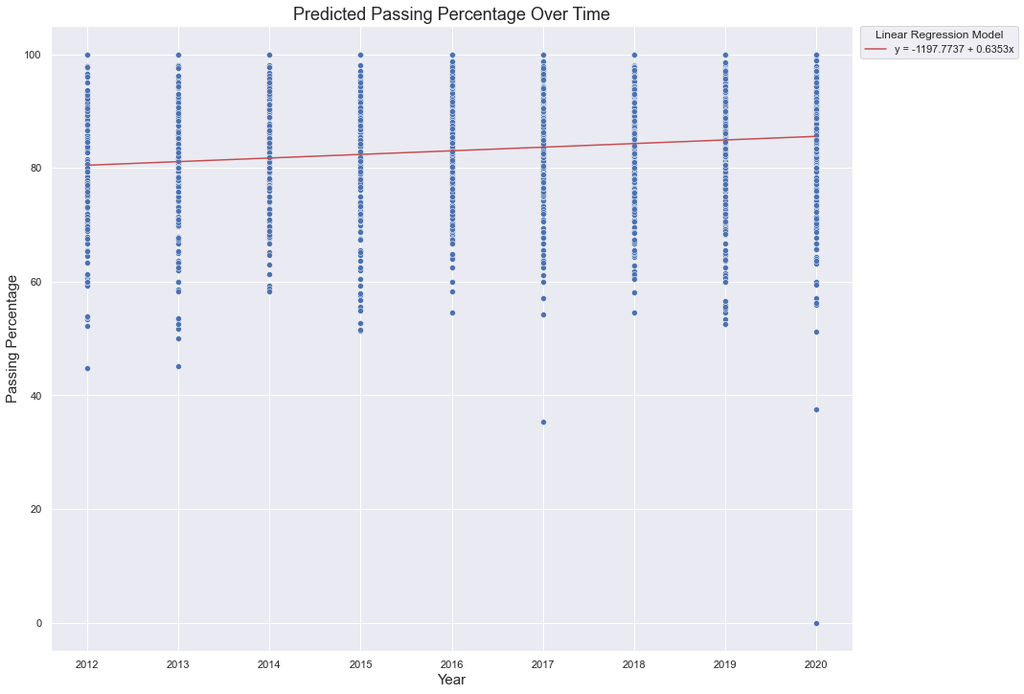

```python
# Covert year column to float.
cs_df['year'] = cs_df['year'].astype(float)

# Set the plot size.
plt.figure(figsize=(15, 12))

# Calculate linear regression.
regline = LinearRegression().fit(cs_df[['year']], cs_df['passing_percentage'])
m = regline.coef_
b = regline.intercept_

# Create a scatterplot to view the regression line.
lin_reg_sct = sns.scatterplot(data=cs_df,
                              x='year',
                              y='passing_percentage')

# Set the labels and title.
lin_reg_sct.set_xlabel('Year',
                       fontsize=15)
lin_reg_sct.set_ylabel('Passing Percentage',
                       fontsize=15)
lin_reg_sct.set_title('Predicted Passing Percentage Over Time',
                      fontsize=18)

# Add the regression line.
plt.plot(cs_df[['year']],
         regline.predict(cs_df[['year']]),
         label=f'y = {b.item():.4f} + {m.item():.4f}x',
         color='r')

# Set legend.
plt.legend(title='Linear Regression Model',
           bbox_to_anchor=(1.01, 1),
           borderaxespad=0)

# Show plot.
plt.show()
```

From the graph above, there is a positive linear increasing trend. Our linear regression equation is:

- y = -1197.7737 + 0.6353x

If we plug in 2021 for x, we get 86.220215. We can conclude that the average pass rate for the CMSC department in 2021 will be **86.22%**.

### 5.2 How has COVID-19 impacted the pass rate in 2020?

While we did get an accurate prediction for the pass rate, we need to address what happened in 2020. The coronavirus pandemic impacted the whole world and the school system. UMD implemented a pass/fail system which heavily influenced the pass rate for Spring 2020. A D- or above was considered passing. We want to know how that affected the pass rate by looking at data between 2019 to 2020.

```python
# Create dataframe from when covid started.
covid_df = cs_df[cs_df['year']>=2019]
covid_df
```

|  | course | section | professor | semester | A+ | A | A- | B+ | B | B- | ... | D | D- | F | W | Other | number_of_grades | passing_grades | passing_percentage | year | department |
| --- | --- | --- | --- | --- | --- | --- | --- | --- | --- | --- | --- | --- | --- | --- | --- | --- | --- | --- | --- | --- | --- |
| 27352 | CMSC132 | 0103 | Larry Herman | 201901 | 1 | 9 | 0 | 1 | 12 | 1 | ... | 1 | 0 | 1 | 2 | 0 | 34 | 30 | 88.24 | 2019.0 | CMSC |
| 27353 | CMSC132 | 0104 | Larry Herman | 201901 | 2 | 4 | 5 | 2 | 12 | 1 | ... | 0 | 0 | 2 | 2 | 0 | 38 | 34 | 89.47 | 2019.0 | CMSC |
| 27335 | CMSC132 | 0301 | Pedram Sadeghian | 201908 | 4 | 6 | 1 | 2 | 0 | 1 | ... | 0 | 0 | 2 | 0 | 0 | 18 | 16 | 88.89 | 2019.0 | CMSC |
| 28479 | CMSC396H | 0101 | David Levin | 201901 | 0 | 27 | 0 | 0 | 0 | 0 | ... | 0 | 0 | 0 | 1 | 0 | 28 | 27 | 96.43 | 2019.0 | CMSC |
| 28491 | CMSC411 | 0101 | Michelle Hugue | 201908 | 3 | 10 | 16 | 32 | 42 | 33 | ... | 0 | 0 | 1 | 4 | 0 | 179 | 174 | 97.21 | 2019.0 | CMSC |
| ... | ... | ... | ... | ... | ... | ... | ... | ... | ... | ... | ... | ... | ... | ... | ... | ... | ... | ... | ... | ... | ... |
| 27299 | CMSC132 | 0305 | Fawzi Emad | 202001 | 0 | 3 | 1 | 2 | 4 | 1 | ... | 0 | 0 | 1 | 3 | 21 | 36 | 32 | 88.89 | 2020.0 | CMSC |
| 27300 | CMSC132 | 0306 | Fawzi Emad | 202001 | 1 | 2 | 3 | 3 | 0 | 1 | ... | 0 | 0 | 2 | 0 | 22 | 35 | 33 | 94.29 | 2020.0 | CMSC |
| 27301 | CMSC132 | 0307 | Fawzi Emad | 202001 | 3 | 5 | 1 | 3 | 2 | 2 | ... | 0 | 0 | 1 | 1 | 17 | 35 | 33 | 94.29 | 2020.0 | CMSC |
| 27303 | CMSC132 | 0401 | Fawzi Emad | 202001 | 1 | 2 | 5 | 2 | 1 | 0 | ... | 0 | 0 | 2 | 0 | 21 | 35 | 33 | 94.29 | 2020.0 | CMSC |
| 28129 | CMSC330 | 0107 | Anwar Mamat | 202001 | 1 | 0 | 1 | 5 | 0 | 2 | ... | 0 | 0 | 0 | 2 | 28 | 40 | 38 | 95.00 | 2020.0 | CMSC |

618 rows × 24 columns

|  | course | section | professor | semester | A+ | A | A- | B+ | B | B- | ... | D | D- | F | W | Other | number_of_grades | passing_grades | passing_percentage | year | department |
| --- | --- | --- | --- | --- | --- | --- | --- | --- | --- | --- | --- | --- | --- | --- | --- | --- | --- | --- | --- | --- | --- |
| 27352 | CMSC132 | 0103 | Larry Herman | 201901 | 1 | 9 | 0 | 1 | 12 | 1 | ... | 1 | 0 | 1 | 2 | 0 | 34 | 30 | 88.24 | 2019.0 | CMSC |
| 27653 | CMSC216 | 0307 | Nelson Padua-Perez | 201901 | 2 | 6 | 3 | 5 | 3 | 3 | ... | 2 | 0 | 4 | 1 | 2 | 35 | 28 | 80.00 | 2019.0 | CMSC |
| 27658 | CMSC216 | 0104 | A.U. Shankar | 201901 | 1 | 0 | 6 | 3 | 1 | 3 | ... | 1 | 0 | 5 | 0 | 2 | 32 | 26 | 81.25 | 2019.0 | CMSC |
| 28345 | CMSC351 | 0201 | Mohammad Nayeem Teli | 201901 | 0 | 2 | 8 | 13 | 29 | 26 | ... | 3 | 2 | 0 | 5 | 0 | 140 | 122 | 87.14 | 2019.0 | CMSC |
| 28344 | CMSC351 | 0301 | Mohammad Nayeem Teli | 201901 | 3 | 9 | 6 | 16 | 22 | 18 | ... | 1 | 2 | 0 | 3 | 0 | 136 | 121 | 88.97 | 2019.0 | CMSC |
| ... | ... | ... | ... | ... | ... | ... | ... | ... | ... | ... | ... | ... | ... | ... | ... | ... | ... | ... | ... | ... | ... |
| 26933 | CMSC131 | 0206 | Fawzi Emad | 202008 | 2 | 8 | 1 | 2 | 4 | 5 | ... | 0 | 0 | 1 | 3 | 0 | 33 | 28 | 84.85 | 2020.0 | CMSC |
| 28519 | CMSC412 | 0101 | Ashok Agrawala | 202008 | 5 | 2 | 3 | 2 | 5 | 6 | ... | 0 | 0 | 2 | 4 | 0 | 39 | 33 | 84.62 | 2020.0 | CMSC |
| 27602 | CMSC216 | 0304 | A Shankar | 202008 | 1 | 3 | 4 | 0 | 1 | 4 | ... | 4 | 0 | 5 | 5 | 0 | 38 | 24 | 63.16 | 2020.0 | CMSC |
| 26931 | CMSC131 | 0204 | Fawzi Emad | 202008 | 2 | 7 | 2 | 4 | 2 | 2 | ... | 0 | 1 | 0 | 5 | 0 | 32 | 26 | 81.25 | 2020.0 | CMSC |
| 28094 | CMSC320 | 0101 | John Dickerson | 202008 | 80 | 94 | 34 | 9 | 16 | 4 | ... | 0 | 0 | 1 | 11 | 1 | 253 | 241 | 95.26 | 2020.0 | CMSC |

618 rows × 24 columns

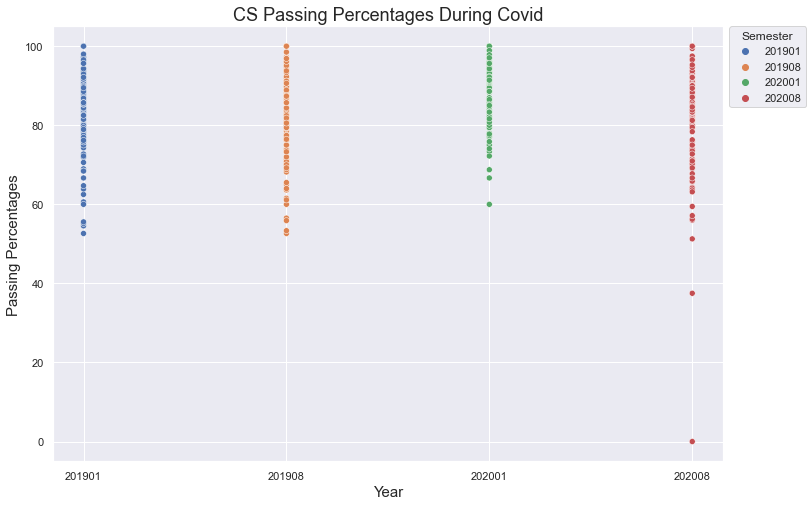

```python
# Sort values by semester.
covid_df = covid_df.sort_values(by='semester')
display(covid_df)

# Set plot size.
fig = plt.figure(figsize=(12, 8))

# Plot scatter plot.
sns.scatterplot(data=covid_df,
                x='semester',
                y='passing_percentage',
                hue='semester')

# Set labels.
plt.xlabel('Year',
           size=15)
plt.ylabel('Passing Percentages',
           size=15)

# Set legend.
plt.legend(title='Semester',
           bbox_to_anchor=(1.01, 1),
           borderaxespad=0)

# Set title.
plt.title('CS Passing Percentages During Covid',
          size=18)

# Show plot.
plt.show()
```

Just by looking at the scatter plot, the concentration of dots in the Spring 2020 semester is closer to the top. Also, there are some outliers in the Fall 2020 semester where classes are failing. We can say that this is not a typical year. To see how much different it is compared to other semesters, we can look at the average and plot it with a line plot.

|  | semester | A+ | A | A- | B+ | B | B- | C+ | C | C- | D+ | D | D- | F | W | Other | number_of_grades | passing_grades | passing_percentage | year |
| --- | --- | --- | --- | --- | --- | --- | --- | --- | --- | --- | --- | --- | --- | --- | --- | --- | --- | --- | --- | --- |
| 0 | 201901 | 3.310345 | 6.751724 | 4.372414 | 5.027586 | 7.620690 | 4.041379 | 3.710345 | 4.124138 | 2.503448 | 0.468966 | 1.786207 | 0.186207 | 1.737931 | 2.551724 | 0.393103 | 48.586207 | 41.855172 | 85.188345 | 2019.0 |
| 1 | 201908 | 3.503067 | 7.288344 | 4.134969 | 4.785276 | 6.509202 | 3.656442 | 2.944785 | 3.699387 | 2.128834 | 0.251534 | 1.521472 | 0.220859 | 2.042945 | 2.877301 | 0.085890 | 45.650307 | 38.736196 | 82.975460 | 2019.0 |
| 2 | 202001 | 5.779221 | 6.811688 | 2.850649 | 2.227273 | 2.077922 | 0.688312 | 0.162338 | 0.142857 | 0.045455 | 0.000000 | 0.006494 | 0.000000 | 1.396104 | 2.175325 | 22.136364 | 46.500000 | 42.922078 | 90.386753 | 2020.0 |
| 3 | 202008 | 5.012821 | 9.333333 | 4.916667 | 5.051282 | 7.000000 | 3.288462 | 2.839744 | 3.230769 | 1.532051 | 0.294872 | 1.108974 | 0.128205 | 1.423077 | 4.217949 | 0.064103 | 49.442308 | 42.269231 | 82.836538 | 2020.0 |

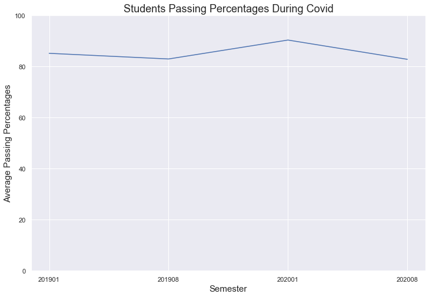

```python
# Dataframe with average values during covid.
covid_df_avg = covid_df.groupby('semester').mean().reset_index()
display(covid_df_avg)

# Set plot size.
fig = plt.figure(figsize=(12, 8))

# Create line plot.
sns.lineplot(data=covid_df_avg,
             x='semester',
             y='passing_percentage')

# Set labels.
plt.xlabel('Semester',
           size=15)
plt.ylabel('Average Passing Percentages',
           size=15)
plt.ylim(0, 100)

# Set title.
plt.title('Students Passing Percentages During Covid',
          size=18)

# Show plot.
plt.show()
```

The line plot confirms our observations. College students in Spring 2020 had an easier time passing, but there may have been lots of other issues impacting their life.

### 6. Communication of Insights Attained

We ended up with many conclusions that may have been lost in the prose above. We want to gather them all in one place and summarize our findings.

1. The CMSC department wasn't in the top 10 at UMD until 2014. In 2020, it is now the **3rd** largest department.
2. The pass rate of the CMSC department is much lower compared to other departments by almost **7%**.
3. The top 10 courses and professors may be too old to be useful.
4. The top 10 Upper-Level Concentration include smaller departments.
5. The average pass rate for CMSC courses has gotten better over time from **81%** to **87%**.
6. The predicted pass rate for 2021 is **86.22%**.
7. COVID-19 had a significant impact on students shown in our analysis. The average pass rate is almost **5%** higher than other semesters.

We expect 2021 to follow the same trend. Students were allowed to choose pass/fail this Spring 2021 semester, but the cutoff is C- or above. The predicted pass rate of **86.22%** with our linear regression model may be slightly higher than the actual pass rate once grades are released for this semester.

Hopefully, with this tutorial, students will feel more comfortable knowing the professors/courses to enroll in future semesters. What the audience can further analyze is the general education courses, and the specific computer science track courses.